# Impact of large dams on species and food webs

Here, we quantify how large dams impact fish communities along the river continuum in four french watersheds (Loire, Somme, Seine, Gironde).

## Summary

**Warning**

To update

We find that

- dams decrease species richness, mostly through migratory and lowland species; this loss may be stronger at high altitude (weak support)
- dams do not credibly change food web structure (trophic length, diet overlap) once the position along the river is properly controlled; at equal richness, a piscivore is slightly more often present with more dams
- top predators are smaller with dams, entirely through the eel: eels are rarer and smaller above dams
- the number of dams matters, not how close they are
- dam effects are confounded with altitude: dams are concentrated in the uplands, where lowland species drop out anyway

## To do

- Add spatial autocorrelation

## Setup

```r
library(renv)
renv::load()
library(targets)
library(here)
tar_config_set(
  store = here::here("_targets")
)
library(ggplot2)
library(dplyr)
devtools::load_all()
nice_theme()
```

## Preparing dam dataset

### Keeping large dams

```r
basin_kept <- tar_read(basin) |>
  filter(district %in% tar_read(params)$district_kept)
roe_kept <- tar_read(roe) |>
  sf::st_filter(sf::st_transform(basin_kept, sf::st_crs(tar_read(roe)))) |>
  sf::st_drop_geometry()
dam_weir_unknown_n <- roe_kept |>
  filter(
    grepl("barrage|seuil", LbTypeOuvrage, ignore.case = TRUE),
    !CdHautChutClObstEcoul %in% as.character(1:8)
  ) |>
  nrow()
large_dam_evidence <- tar_read(large_dam) |>
  sf::st_filter(sf::st_transform(basin_kept, sf::st_crs(tar_read(large_dam)))) |>
  sf::st_drop_geometry() |>
  count(evidence)
evidence_n <- setNames(large_dam_evidence$n, large_dam_evidence$evidence)
large_dam_n <- sum(evidence_n)
```

We use the ROE database from OFB. The database lists artificial obstacles in French rivers. We keep dams and weirs with a drop height of 5 meters or more. We keep four dams marked as destroyed they were removed at the very end of our sampling or after.

The drop height class is missing for many obstacles, some large dam may be among them.

Obstacles only matter here if they lie on the river network with sampled sites upstream of them. Each obstacle is snapped on the network with a threshold of 100 m.

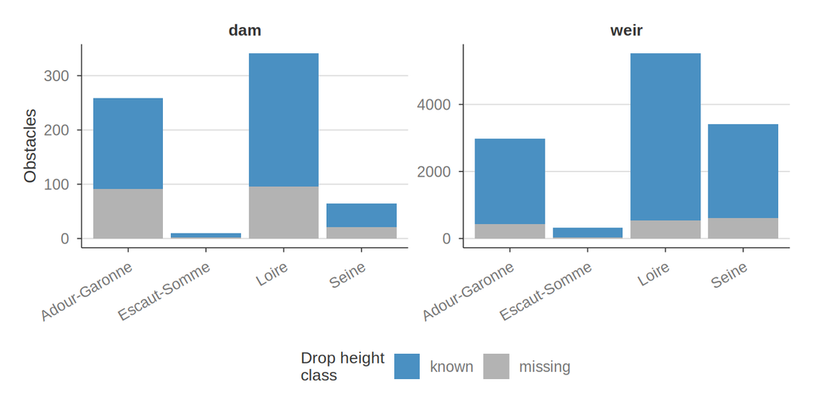

```r
district_label <- c(
  "Ardour-Garonne" = "Adour-Garonne", "Escaut-Somme" = "Escaut-Somme",
  "Loire" = "Loire", "Seine" = "Seine"
)
dam_network <- tar_read(dam_network)$network
river_edge <- sf::st_as_sf(tar_read(river_network_geo)$edges)
obstacle <- tar_read(roe) |>
  sf::st_join(
    sf::st_transform(select(basin_kept, district), sf::st_crs(tar_read(roe))),
    join = sf::st_within, left = FALSE
  ) |>
  sf::st_transform(sf::st_crs(river_edge)) |>
  transmute(
    roe_code = CdObstEcoul,
    district = district_label[district],
    kind = if_else(grepl("seuil", LbTypeOuvrage, ignore.case = TRUE), "weir", "dam"),
    drop_class = if_else(CdHautChutClObstEcoul %in% as.character(1:8), "known", "missing"),
    group = case_when(
      !LbEtOuvrage %in% c("Existant", "Détruit entièrement", "Détruit partiellement") ~ "planned or no status",
      !grepl("barrage|seuil", LbTypeOuvrage, ignore.case = TRUE) ~ "other type",
      roe_code %in% tar_read(large_dam)$roe_code ~ "large (kept)",
      CdHautChutClObstEcoul %in% as.character(1:6) ~ "small (< 5 m)",
      TRUE ~ "unknown size"
    )
  )
dam_weir <- filter(obstacle, group %in% c("large (kept)", "small (< 5 m)", "unknown size"))
dam_weir$snap_dist_m <- as.numeric(sf::st_distance(
  dam_weir, river_edge[sf::st_nearest_feature(dam_weir, river_edge), ], by_element = TRUE
))
dam_weir_on <- filter(dam_weir, snap_dist_m <= 100)
network_node <- sf::st_as_sf(dam_network$nodes)
dam_weir_on$node_id <- network_node$node_id[sf::st_nearest_feature(dam_weir_on, network_node)]
dam_weir_visit <- locate_operations_dams(
  dam_network,
  tar_read(inland_operations_snapped) |> filter(survey == "river"),
  dam_weir_on,
  tar_read(river_mouth_district)
) |>
  filter(position == "upstream", operation_id %in% tar_read(dam_visit)$operation_id) |>
  distinct(roe_code)
dam_weir <- dam_weir |>
  sf::st_drop_geometry() |>
  mutate(
    position = case_when(
      snap_dist_m > 100 ~ "too far from the network (> 100 m)",
      roe_code %in% dam_weir_visit$roe_code ~ "on the network, sites upstream",
      TRUE ~ "on the network, no site upstream"
    )
  )
dam_weir_relevant <- filter(dam_weir, position == "on the network, sites upstream")
dam_weir_relevant |>
  count(district, kind, drop_class) |>
  ggplot(aes(district, n, fill = drop_class)) +
  geom_col() +
  facet_wrap(~kind, scales = "free_y") +
  scale_fill_manual(values = c(known = "#4A90C2", missing = "grey70")) +
  labs(x = NULL, y = "Obstacles", fill = "Drop height\nclass") +
  theme(axis.text.x = element_text(angle = 30, hjust = 1))
```

Dams and weirs on the network with sampled sites upstream, with a known or missing drop height class.

For the obstacles of unknown class, the drop height is inferred from the structure height, when it is available. Drop height raises with obstacle height.

From available data, we use the following thresholds:

1. A dam of 7.5 m or more is set to a drop of 5 m or more
2. A dam of 15 m or more is set to a drop of 10 m or more

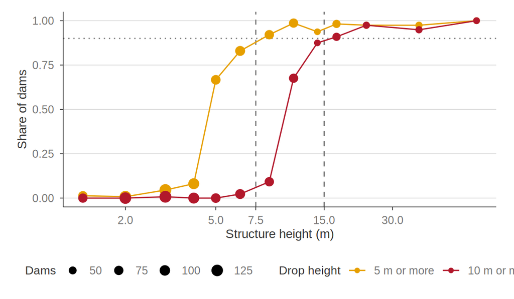

```r
tar_read(roe) |>
  sf::st_drop_geometry() |>
  filter(
    LbEtOuvrage == "Existant",
    grepl("barrage", LbTypeOuvrage, ignore.case = TRUE),
    CdHautChutClObstEcoul %in% as.character(1:8)
  ) |>
  mutate(structure_height = suppressWarnings(as.numeric(HautMaxTer))) |>
  filter(structure_height > 0) |>
  mutate(band = cut(structure_height, c(0, 2, 3, 4, 5, 6, 7.5, 10, 12.5, 15, 20, 30, 50, Inf), right = FALSE)) |>
  summarise(
    height = median(structure_height), dams = n(),
    `5 m or more` = mean(CdHautChutClObstEcoul %in% c("7", "8")),
    `10 m or more` = mean(CdHautChutClObstEcoul == "8"),
    .by = band
  ) |>
  tidyr::pivot_longer(c(`5 m or more`, `10 m or more`), names_to = "drop", values_to = "share") |>
  mutate(drop = factor(drop, c("5 m or more", "10 m or more"))) |>
  ggplot(aes(height, share, color = drop)) +
  geom_vline(xintercept = c(7.5, 15), linetype = "dashed", color = "grey50") +
  geom_hline(yintercept = 0.9, linetype = "dotted", color = "grey50") +
  geom_line() +
  geom_point(aes(size = dams)) +
  scale_x_log10(breaks = c(1, 2, 5, 7.5, 15, 30, 100)) +
  scale_color_manual(values = c("#E69F00", "#B2182B")) +
  scale_size_area(max_size = 4) +
  labs(x = "Structure height (m)", y = "Share of dams", color = "Drop height", size = "Dams")
```

The measured drop height and the structure height of weirs are not used: they hold impossible values (weirs of tens to hundreds of meters, often their length).

Large dams whose drop height class and structure height are both missing are left out: we may miss some, but we assume that we keep most of them.

This leaves us with 1,585 obstacles (hereafter “dams” for simplicity): 1,148 from their drop height class and 437 from their structure height. The table below gives why the other obstacles are left out.

```r
options(knitr.kable.NA = "")
bind_rows(
  sf::st_drop_geometry(obstacle) |>
    filter(!group %in% dam_weir$group) |>
    count(group, name = "total"),
  dam_weir |>
    count(group, kind, position) |>
    tidyr::pivot_wider(names_from = position, values_from = n, values_fill = 0) |>
    mutate(total = rowSums(across(where(is.numeric))))
) |>
  mutate(group = factor(group, c(
    "large (kept)", "small (< 5 m)", "unknown size",
    "other type", "planned or no status"
  ))) |>
  arrange(group, kind) |>
  select(
    group, kind, total, `too far from the network (> 100 m)`,
    `on the network, no site upstream`, `on the network, sites upstream`
  ) |>
  knitr::kable(format.args = list(big.mark = ","))
```

| group | kind | total | too far from the network (> 100 m) | on the network, no site upstream | on the network, sites upstream |
| --- | --- | --- | --- | --- | --- |
| large (kept) | dam | 1,376 | 231 | 975 | 170 |
| large (kept) | weir | 209 | 3 | 145 | 61 |
| small (< 5 m) | dam | 4,432 | 699 | 3,414 | 319 |
| small (< 5 m) | weir | 36,909 | 544 | 25,804 | 10,561 |
| unknown size | dam | 6,916 | 1,869 | 4,861 | 186 |
| unknown size | weir | 8,108 | 357 | 6,150 | 1,601 |
| other type |  | 16,382 |  |  |  |
| planned or no status |  | 2,660 |  |  |  |

Here is the number of obstacles per catchment, height and kind.

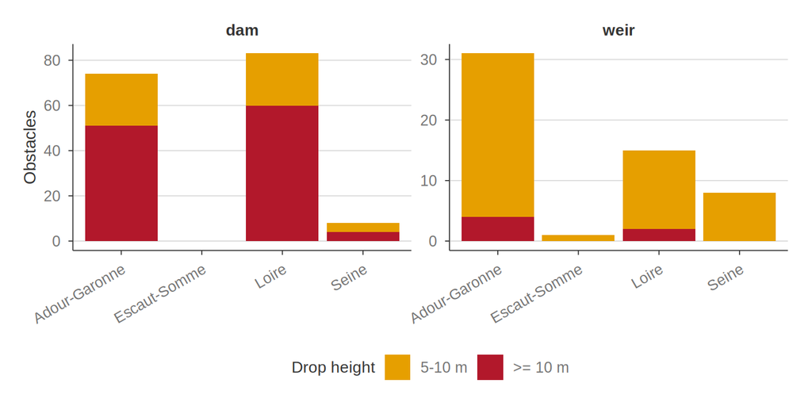

```r
district_label <- c(
  "Ardour-Garonne" = "Adour-Garonne", "Escaut-Somme" = "Escaut-Somme",
  "Loire" = "Loire", "Seine" = "Seine"
)
dam_with_site <- tar_read(operation_dam) |>
  filter(position == "upstream", operation_id %in% tar_read(dam_visit)$operation_id) |>
  distinct(roe_code)
large_dam_district <- tar_read(large_dam) |>
  semi_join(dam_with_site, by = "roe_code") |>
  sf::st_join(
    tar_read(basin) |>
      filter(district %in% tar_read(params)$district_kept) |>
      sf::st_transform(sf::st_crs(tar_read(large_dam))) |>
      select(district),
    join = sf::st_within, left = FALSE
  ) |>
  sf::st_drop_geometry() |>
  mutate(
    district = district_label[district],
    drop_height = factor(drop_height_min, c(5, 10), c("5-10 m", ">= 10 m"))
  )
large_dam_district |>
  count(district, kind, drop_height) |>
  ggplot(aes(district, n, fill = drop_height)) +
  geom_col() +
  facet_wrap(~kind, scales = "free_y") +
  scale_fill_manual(values = c("#E69F00", "#B2182B")) +
  labs(x = NULL, y = "Obstacles", fill = "Drop height") +
  theme(axis.text.x = element_text(angle = 30, hjust = 1))
```

### Placing the dams on the river network

The dams between a site and the sea are counted along the river network. Each dam is placed on the network from its own ROE coordinates, in four steps:

1. **Snapping.** The dam is placed on the nearest river segment, if it is within 100 m of the ROE coordinates.
2. **River name.** When a segment bearing the ROE river name lies within 100 m, it is preferred to a nearer segment of another river.
3. **Close dams.** Dams less than 1 km apart on the same flow path count as one. They act as one barrier for fish moving along the river (and are often two ROE codes of one structure, such as a weir and its power plant). Going up from the sea, a dam is merged into the nearest kept dam downstream if it lies within 1 km of it.
4. **Routing.** The dams of a site are those on its route to the sea, the shortest path through the network to the river mouth, which also gives the distance to the mouth. We penalize artificial canals such that they count 100 times their length for the choice of the route only. We do so because sometimes the shortest path to the sea was going through them, masking the dams of the natural riverbed or adding dams of the canal.

Here is the table of the dams that are snapped from distance, snapped using river name, merged (if close), and eventually left out.

```r
large_dam <- tar_read(large_dam)
basin_kept <- tar_read(basin) |>
  filter(district %in% tar_read(params)$district_kept) |>
  sf::st_transform(sf::st_crs(large_dam))
large_dam_kept <- large_dam |>
  sf::st_filter(basin_kept) |>
  mutate(
    drop_height = factor(drop_height_min, c(5, 10), c("5-10 m", ">= 10 m")),
    match = factor(coalesce(match, "left out"), c("nearest", "name", "merged", "left out"))
  )
placement <- sf::st_drop_geometry(large_dam_kept) |>
  mutate(placed = match %in% c("nearest", "name"))
placed_dist <- placement$snap_dist_m[placement$placed]
left_far <- filter(placement, match == "left out")
sf::st_drop_geometry(large_dam_kept) |>
  count(kind, match) |>
  tidyr::pivot_wider(names_from = match, values_from = n, values_fill = 0)
```

```
# A tibble: 2 × 5
  kind  nearest  name merged `left out`
  <chr>   <int> <int>  <int>      <int>
1 dam      1075    21     49        231
2 weir      185     3     18          3
```

And here is the distribution of the snapping distance for the dams that are kept.

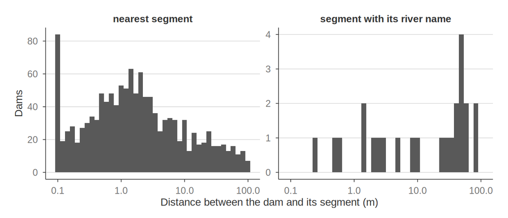

```r
large_dam_kept |>
  sf::st_drop_geometry() |>
  filter(match %in% c("nearest", "name")) |>
  mutate(
    match = factor(match, c("nearest", "name"), c("nearest segment", "segment with its river name"))
  ) |>
  ggplot(aes(pmax(snap_dist_m, 0.1))) +
  geom_histogram(bins = 40) +
  facet_wrap(~match, scales = "free_y") +
  scale_x_log10(labels = scales::label_number()) +
  labs(x = "Distance between the dam and its segment (m)", y = "Dams")
```

The other 234 dams (15%) are left out because they lie more than 100 m from any river segment (median 320 m), mostly pond and reservoir embankments on small streams the network does not include. To check that leaving them out does not matter, each was placed on its nearest network node and the visits upstream of it were counted.

```r
dam_network <- tar_read(dam_network)$network
network_node <- sf::st_as_sf(dam_network$nodes)
left_out <- large_dam_kept |>
  filter(match == "left out") |>
  sf::st_transform(sf::st_crs(network_node))
left_out$node_id <- network_node$node_id[sf::st_nearest_feature(left_out, network_node)]
left_out_visit <- locate_operations_dams(
  dam_network,
  tar_read(inland_operations_snapped) |> filter(survey == "river"),
  left_out,
  tar_read(river_mouth_district)
) |>
  filter(position == "upstream", operation_id %in% tar_read(dam_visit)$operation_id) |>
  count(roe_code, name = "visits_upstream")
left_out_upstream <- left_out |>
  sf::st_drop_geometry() |>
  inner_join(left_out_visit, by = "roe_code")
left_out_upstream |>
  transmute(roe_code, name, type, distance_m = round(snap_dist_m), visits_upstream) |>
  arrange(desc(visits_upstream)) |>
  knitr::kable()
```

| roe_code | name | type | distance_m | visits_upstream |
| --- | --- | --- | --- | --- |
| ROE62492 | LACALM | Barrage | 398 | 37 |
| ROE62494 | LA TEOULETTE | Barrage | 227 | 37 |
| ROE62882 | LA RAMEGE | Barrage | 586 | 37 |
| ROE82718 | Plan d’eau Le Chêne vert | Barrage en remblais | 323 | 16 |
| ROE71880 | Etang de Lièvresault (Landronnière) aval | Barrage en remblais | 490 | 10 |
| ROE97970 | busage entre 2 douves du chateau | Autre sous-type de seuil en rivière | 163 | 10 |
| ROE62706 | Tendy | Barrage | 438 | 8 |
| ROE68545 | RIEU COUCHET | Barrage | 589 | 8 |
| ROE38147 | Seuil du moulin des moines insoumis | Seuil en rivière déversoir | 316 | 7 |
| ROE76309 | Retenue d’Anchald | Barrage | 212 | 3 |
| ROE62679 | LEZAT-SUR-LEZE_LEZE_DE SMIDT DENIS | Barrage | 267 | 2 |
| ROE96701 | Plan d’eau de Ménuse | Barrage en remblais | 150 | 2 |
| ROE62825 | PUECH LE LONG | Barrage | 465 | 1 |
| ROE91327 | Plan d’eau de Laborde 47001501 | Barrage | 676 | 1 |
| ROE98900 | Plan d’eau de Roussignon 47001705 | Barrage en remblais | 682 | 1 |

Only 15 of the 234 dams left out for their distance would have sampled visits upstream (180 visits in all), and these lie 150 to 680 m from the network, mostly pond dams: placing them on the nearest node would put them on the river next to the pond, where they do not stand. The left-out dams therefore do not change the dam counts of the sites.

Large dams on the network with sampled sites upstream (those that enter the dam counts of the sites), by drop height class and kind, on the RHT rivers of Strahler order 3 or more.

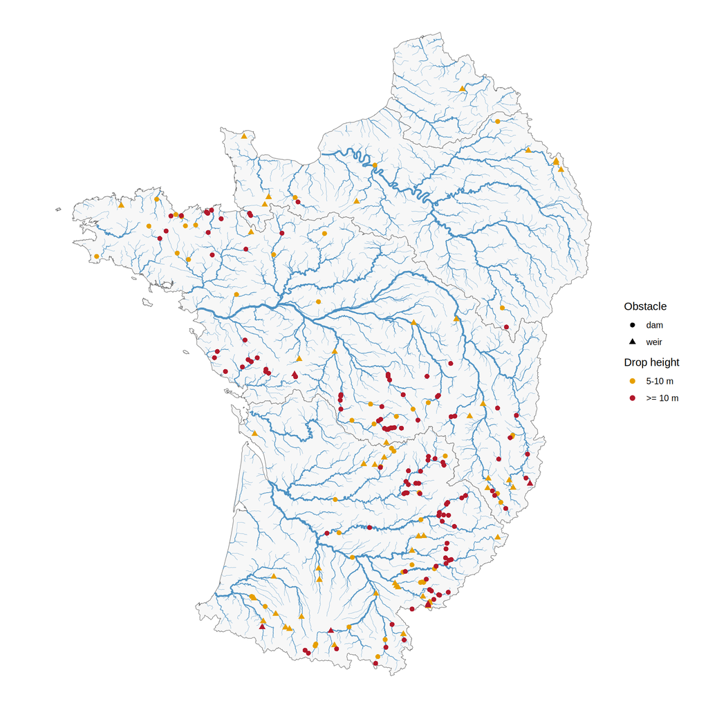

```r
rht <- tar_read(rht)
river_line <- rht |>
  filter(strahler >= 3) |>
  sf::st_transform(sf::st_crs(large_dam)) |>
  sf::st_filter(basin_kept)
ggplot() +
  geom_sf(data = basin_kept, fill = "grey97", color = "grey40") +
  geom_sf(data = river_line, aes(linewidth = strahler), color = "#4A90C2") +
  geom_sf(
    data = large_dam_kept |> semi_join(dam_with_site, by = "roe_code") |> arrange(drop_height_min),
    aes(color = drop_height, shape = kind), size = 2
  ) +
  scale_linewidth(range = c(0.1, 1), guide = "none") +
  scale_shape_manual(name = "Obstacle", values = c(dam = 16, weir = 17)) +
  scale_color_manual(name = "Drop height", values = c("#E69F00", "#B2182B")) +
  theme_void()
```

### How dams accumulate along the river network

An operation is upstream of a dam if the dam lies on its path to the mouth, and downstream if it lies on the dam’s path to the mouth (`operation_dam`, river operations).

```r
operation_dam <- tar_read(operation_dam) |>
  left_join(
    tar_read(river_operation) |> distinct(operation_id, sandre_code),
    by = "operation_id"
  ) |>
  left_join(
    large_dam |> sf::st_drop_geometry() |> select(roe_code, kind, drop_height_min),
    by = "roe_code"
  )
river_ops <- tar_read(inland_operations_snapped) |>
  filter(survey == "river") |>
  left_join(
    tar_read(inland_distance_to_mouth) |> select(operation_id, dist_mouth_m),
    by = "operation_id"
  )

dam_below <- operation_dam |>
  filter(position == "upstream") |>
  count(operation_id, name = "dams")
river_ops <- river_ops |>
  left_join(dam_below, by = "operation_id") |>
  mutate(dams = coalesce(dams, 0L))

river_ops |>
  summarise(operations = n(), with_dam_below = mean(dams > 0))
```

```
  operations with_dam_below
1      14359      0.4167421
```

Number of large dams between each operation and the sea.

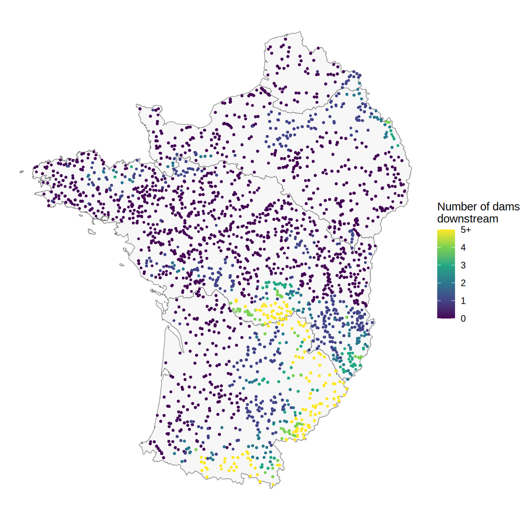

```r
river_ops |>
  ggplot(aes(longitude, latitude, color = pmin(dams, 5))) +
  geom_sf(
    data = sf::st_transform(basin_kept, 4326), fill = "grey97",
    color = "grey40", inherit.aes = FALSE
  ) +
  geom_point(size = 0.6) +
  scale_color_viridis_c(name = "Number of dams\ndownstream", labels = c(0:4, "5+")) +
  theme_void()
```

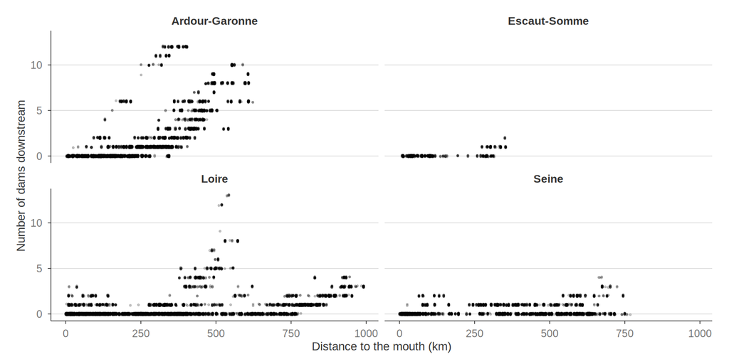

```r
ggplot(river_ops, aes(dist_mouth_m / 1000, dams)) +
  geom_jitter(height = 0.1, size = 0.5, alpha = 0.2) +
  facet_wrap(~district) +
  labs(x = "Distance to the mouth (km)", y = "Number of dams downstream")
```

## A case study with Mervent and Tuilières dams

Before modelling France, we look at two specific dams: Mervent (Vendée) and Tuilières (Dordogne). Mervent is the first large dam from the sea on the Vendée. Tuilières is the first large dam on the Dordogne. We compare fishing operations within 100km upstream and dowstream of each dam (same flow path).

```r
focus_dam <- c(Mervent = "ROE39720", Tuilieres = "ROE66029")
migratory <- c(
  "Anguilla anguilla", "Salmo salar", "Petromyzon marinus",
  "Lampetra fluviatilis", "Platichthys flesus", "Chelon ramada", "Chelon auratus"
)
river_effort <- tar_read(river_effort)

focus_operation <- operation_dam |>
  filter(roe_code %in% focus_dam, river_dist_m <= 100000) |>
  mutate(dam = names(focus_dam)[match(roe_code, focus_dam)]) |>
  left_join(river_effort, by = "operation_id")
```

Occurrence of each species downstream and upstream of each dam, for the operations with individual fish records: the share of visits where it is caught at each site, averaged over the sites (each site weighs the same, however often it was visited). The effect of the dam is summarised by the difference in occurrence (upstream minus downstream; negative: less frequent upstream).

```r
focus_presence <- tar_read(river_size) |>
  mutate(operation_id = as.character(operation_id)) |>
  semi_join(focus_operation, by = "operation_id") |>
  distinct(operation_id, species_valid)

focus_species <- focus_operation |>
  filter(has_individuals) |>
  tidyr::crossing(species_valid = unique(focus_presence$species_valid)) |>
  left_join(
    focus_presence |> mutate(present = TRUE),
    by = c("operation_id", "species_valid")
  ) |>
  summarise(
    occurrence = mean(coalesce(present, FALSE)),
    .by = c(dam, species_valid, position, sandre_code)
  ) |>
  summarise(occurrence = mean(occurrence), .by = c(dam, species_valid, position)) |>
  tidyr::pivot_wider(
    names_from = position, values_from = occurrence, names_prefix = "occurrence_"
  ) |>
  mutate(
    difference = occurrence_upstream - occurrence_downstream,
    migratory = species_valid %in% migratory
  )

focus_operation |>
  filter(has_individuals) |>
  summarise(operations = n(), sites = n_distinct(sandre_code), .by = c(dam, position))
```

```
        dam   position operations sites
1 Tuilieres   upstream         18    13
2   Mervent   upstream          8     3
3 Tuilieres downstream          3     2
4   Mervent downstream          4     1
```

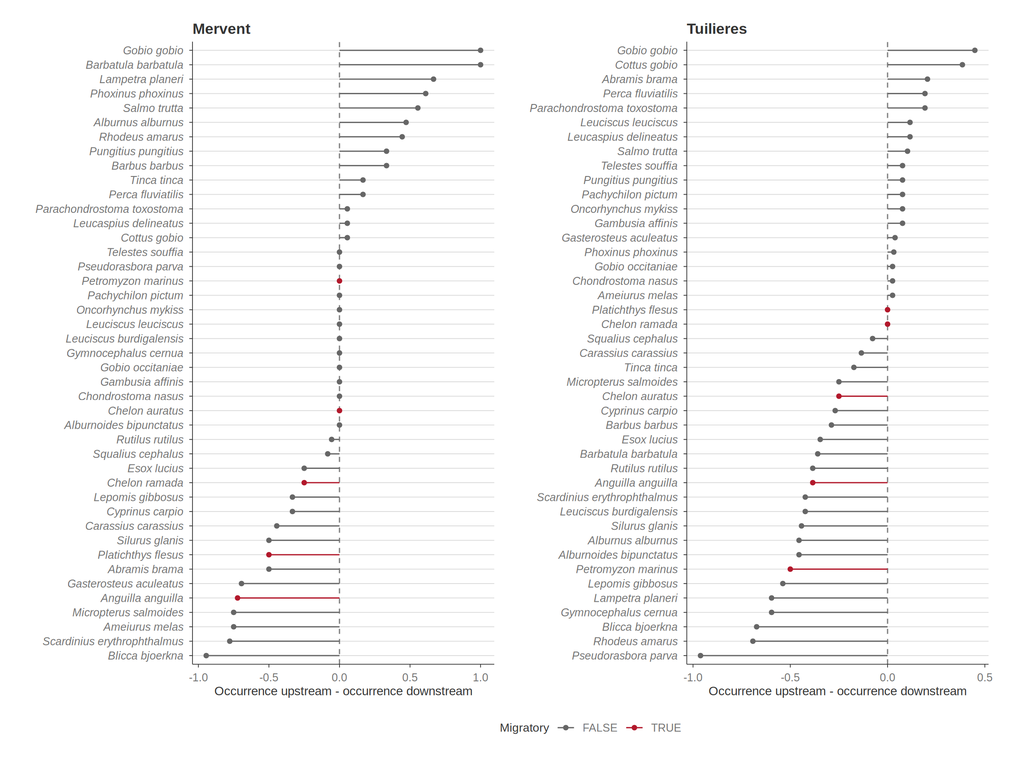

```r
difference_plot <- function(dam_name) {
  focus_species |>
    filter(dam == dam_name) |>
    mutate(species_valid = reorder(species_valid, difference)) |>
    ggplot(aes(difference, species_valid, color = migratory)) +
    geom_vline(xintercept = 0, linetype = "dashed", color = "grey50") +
    geom_segment(aes(x = 0, xend = difference, yend = species_valid)) +
    geom_point() +
    scale_color_manual(values = c(`FALSE` = "grey40", `TRUE` = "#B2182B")) +
    labs(
      title = dam_name, x = "Occurrence upstream - occurrence downstream",
      y = NULL, color = "Migratory"
    ) +
    theme(axis.text.y = element_text(face = "italic"))
}
patchwork::wrap_plots(lapply(names(focus_dam), difference_plot), guides = "collect")
```

Upstream of dams species that migrate from the sea (e.g. eels) decreases. Dams slow down their migration further upstream in the river. This is the main expected impact of dams.

## Presence models

### Measuring dam impact

We focus on the impact of dams preventing fish migration. To capture this effect we use the number of dam downstream of a site. This captures the barrier effect between the site and the sea. An important thing to have in mind is that accumulation of dams increases as we go upstream (see below).

```r
continuum_operation <- tar_read(continuum_operation)
species_min_sites <- 100 # Species modelled: present at >= this number of sites.

presence <- tar_read(size_year_filtered) |>
  filter(survey == "river") |>
  distinct(operation_id, species_valid)

dam_accumulation <- operation_dam |>
  filter(position == "upstream") |>
  summarise(dam_count = sum(kind == "dam"), weir_count = sum(kind == "weir"), .by = operation_id)

operation_mouth <- tar_read(inland_distance_to_mouth) |>
  semi_join(presence, by = "operation_id") |>
  assign_river_mouth(
    tar_read(river_network),
    operation = _,
    river_mouth = sf::st_drop_geometry(tar_read(river_mouth_district))
  ) |>
  select(operation_id, mouth_node, dist_mouth_m)

visit <- continuum_operation |>
  select(operation_id, longitude, latitude, district, PC1, PC2, log_altitude, log_slope) |>
  filter(!is.na(log_altitude)) |>
  semi_join(presence, by = "operation_id") |>
  inner_join(
    tar_read(river_operation) |> distinct(operation_id, sandre_code, date, year),
    by = "operation_id"
  ) |>
  left_join(river_effort |> select(operation_id, protocol, surface), by = "operation_id") |>
  filter(!is.na(surface)) |>
  left_join(
    tar_read(inland_operations_rht) |>
      sf::st_drop_geometry() |>
      select(operation_id, altitude, july_temperature = tjuil_moy),
    by = "operation_id"
  ) |>
  left_join(dam_accumulation, by = "operation_id") |>
  inner_join(operation_mouth, by = "operation_id") |>
  left_join(
    tar_read(continuum_variables_operation) |> select(operation_id, log_width),
    by = "operation_id"
  ) |>
  mutate(
    dam_count = coalesce(dam_count, 0L),
    weir_count = coalesce(weir_count, 0L),
    dams = dam_count + weir_count,
    log_dist = log(dist_mouth_m / 1000) - mean(log(dist_mouth_m / 1000)),
    log_alt = log_altitude - mean(log_altitude),
    log_slope = log_slope - mean(log_slope),
    width = exp(log_width),
    log_width = log_width - mean(log_width),
    catchment = as.integer(factor(mouth_node)),
    # Indices for INLA.
    log_surface = log(surface),
    site = as.integer(factor(sandre_code))
  )
c(
  visits = nrow(visit), sites = n_distinct(visit$sandre_code),
  catchments = n_distinct(visit$catchment)
)
```

```
    visits      sites catchments
      5929       1685         91
```

```r
# Position controls of all models, and their coefficients.
control_term <- "log_width + log_alt + I(log_alt^2) + log_dist"
control_coef <- c("log_width", "log_alt", "I(log_alt^2)", "log_dist")
```

Number of large dams and large weirs between each site and the sea against the altitude and the distance to the mouth (one point per site).

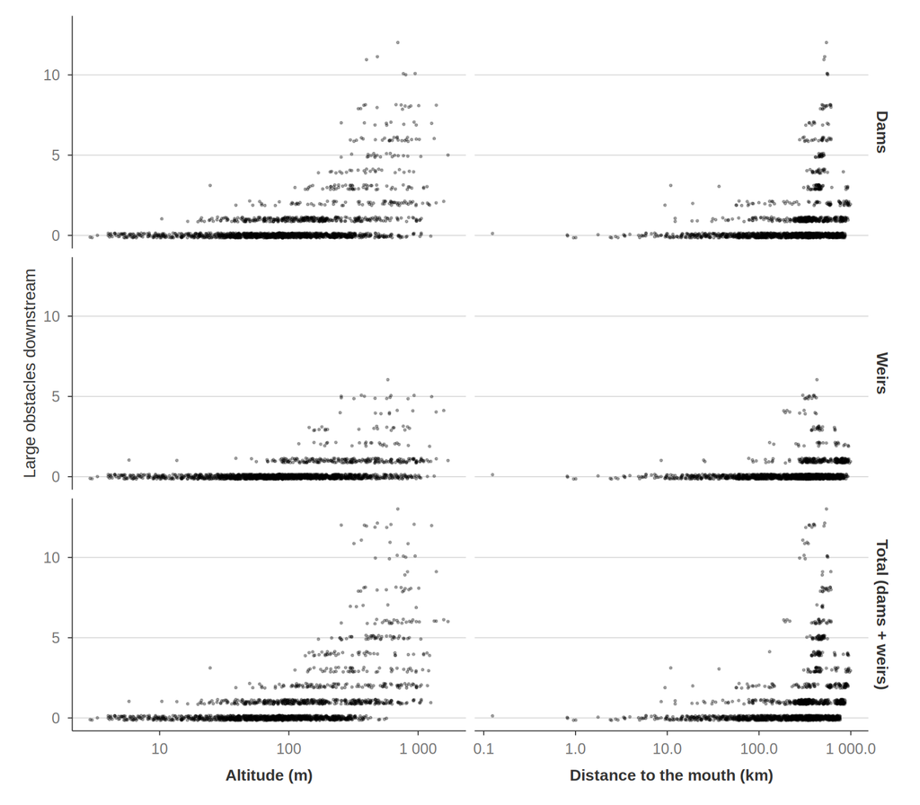

```r
visit_site <- distinct(visit, sandre_code, .keep_all = TRUE)
visit_site |>
  transmute(
    sandre_code, dam_count, weir_count, dams,
    altitude = exp(log_altitude), distance = dist_mouth_m / 1000
  ) |>
  tidyr::pivot_longer(c(dam_count, weir_count, dams), names_to = "obstacle", values_to = "count") |>
  tidyr::pivot_longer(c(altitude, distance), names_to = "axis", values_to = "value") |>
  mutate(
    obstacle = factor(obstacle, c("dam_count", "weir_count", "dams"), c("Dams", "Weirs", "Total (dams + weirs)")),
    axis = factor(axis, c("altitude", "distance"), c("Altitude (m)", "Distance to the mouth (km)"))
  ) |>
  ggplot(aes(value, count)) +
  geom_jitter(height = 0.15, width = 0, size = 0.4, alpha = 0.3) +
  facet_grid(obstacle ~ axis, scales = "free_x", switch = "x") +
  scale_x_log10(labels = scales::label_number()) +
  labs(x = NULL, y = "Large obstacles downstream") +
  theme(strip.placement = "outside")
```

### Designing the model

Next, we model the impact downstream dam accumulation on species presence. When designing our model we have to be careful to include enough environment variables such that model can disentangle the effect of environments and dams. These effects are correlated if we for example consider elevation. We have also to ensure that the model is identifiable. Many environmental covariables are correlated such that including too many of them may harm the model. To ensure this doesn’t happen we check the variance inflation factor (VIF) of each model term. VIF enables to quantify the collinearity of each term with others, which informs on how adding this term to the model inflates the model uncertainty. VIF below 5 indicates low to moderate collinearity and is generally acceptable. VIF higher than 10 indicates severe collinearity making the model non-identifiable (Dormann et al. 2013).

Once the models are designed, we will also investigate posterior correlations to ensure that the model is able to disentangle covariable effects.

Here is the list of our fixed effect candidates:

- dam impacts (included by default)
- river width
- altitude
- distance to river mouth
- slope
- strahler order

Below we plot their pairwise correlations (Spearman) and their VIF, so we can better decide which one to include.

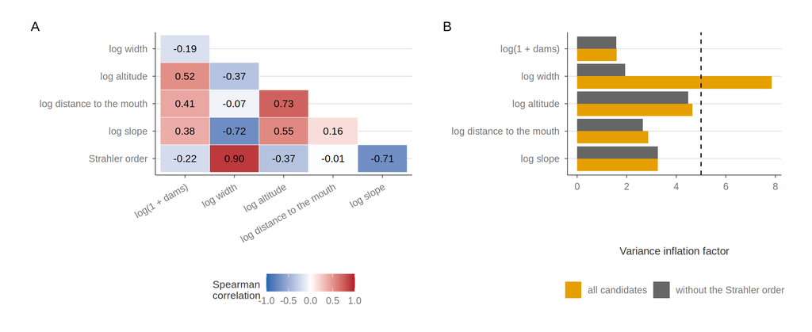

```r
position_variable <- visit |>
  left_join(continuum_operation |> select(operation_id, strahler), by = "operation_id") |>
  transmute(
    `log(1 + dams)` = log1p(dams), `log width` = log_width, `log altitude` = log_alt,
    `log distance to the mouth` = log_dist, `log slope` = log_slope, `Strahler order` = strahler
  )
position_correlation <- cor(position_variable, method = "spearman")
correlation_plot <- as_tibble(position_correlation, rownames = "x") |>
  tidyr::pivot_longer(-x, names_to = "y", values_to = "rho") |>
  mutate(
    x = factor(x, colnames(position_correlation)),
    y = factor(y, rev(colnames(position_correlation)))
  ) |>
  filter(as.integer(x) < ncol(position_correlation) + 1 - as.integer(y)) |>
  ggplot(aes(x, y, fill = rho)) +
  geom_tile(color = "white") +
  geom_text(aes(label = sprintf("%.2f", rho)), size = 3.5) +
  scale_fill_gradient2(low = "#2166AC", high = "#B2182B", limits = c(-1, 1)) +
  labs(x = NULL, y = NULL, fill = "Spearman\ncorrelation") +
  theme(axis.text.x = element_text(angle = 30, hjust = 1), panel.grid = element_blank())
vif <- function(term) {
  sapply(term, \(k) {
    1 / (1 - summary(lm(reformulate(sprintf("`%s`", setdiff(term, k)), sprintf("`%s`", k)), position_variable))$r.squared)
  })
}
candidate_term <- colnames(position_variable)
reduced_term <- setdiff(candidate_term, "Strahler order")
position_vif <- bind_rows(
  tibble(term = candidate_term, vif = vif(candidate_term), set = "all candidates"),
  tibble(term = reduced_term, vif = vif(reduced_term), set = "without the Strahler order")
)
vif_plot <- position_vif |>
  filter(term != "Strahler order") |>
  mutate(term = factor(term, rev(candidate_term))) |>
  ggplot(aes(vif, term, fill = set)) +
  geom_col(position = position_dodge(preserve = "single")) +
  geom_vline(xintercept = 5, linetype = "dashed") +
  scale_fill_manual(values = c("#E69F00", "grey40")) +
  labs(x = "Variance inflation factor", y = NULL, fill = NULL) +
  theme(legend.position = "bottom")
patchwork::wrap_plots(correlation_plot, vif_plot, widths = c(1.2, 1)) +
  patchwork::plot_annotation(tag_levels = "A")
```

Strahler order and river width tells the same thing: they are strongly correlated, and including both raise the VIF beyond 5. We’ll go for river width only. All other variables can be safely included, as they are not too strongly correlated, and their VIF lies safely below 5.

### Fitting the first model

We test a first model that include all these covariables (linear), and the following random effects:

- year
- site
- spatial random field to handle spatial autocorrelation

A catchment effect was also tried, but its variance was estimated at almost zero for both species (about $10^{-4}$, against 2.3 for the site effect of the gudgeon): once the spatial field is in, the catchments add nothing, so it is left out.

To begin with we need to generate a mesh for the spatial random field.

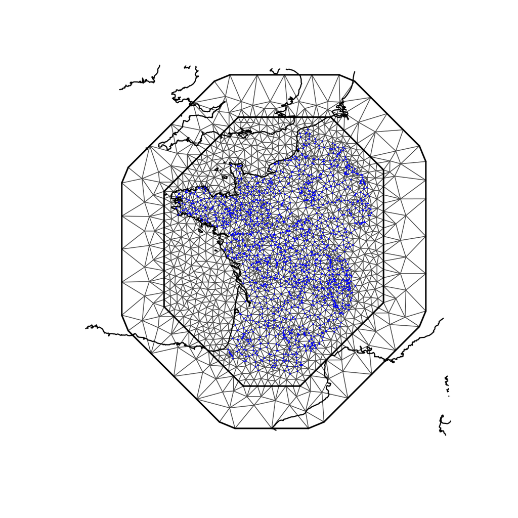

```r
# Spatial random field of the presence models: SPDE mesh over the sites
# (Lambert-93, km) and projection of the field at the visits.
site_xy <- visit |>
  sf::st_as_sf(coords = c("longitude", "latitude"), crs = 4326) |>
  sf::st_transform(2154) |>
  sf::st_coordinates() / 1000
spatial_mesh <- INLA::inla.mesh.2d(loc = unique(site_xy), max.edge = c(40, 150), cutoff = 5)
spde <- INLA::inla.spde2.pcmatern(
  spatial_mesh, prior.range = c(50, 0.5), prior.sigma = c(1, 0.01)
)
spatial_A <- INLA::inla.spde.make.A(spatial_mesh, loc = site_xy)
mesh_box <- sf::st_bbox(c(
  xmin = min(spatial_mesh$loc[, 1]), xmax = max(spatial_mesh$loc[, 1]),
  ymin = min(spatial_mesh$loc[, 2]), ymax = max(spatial_mesh$loc[, 2])
) * 1000, crs = sf::st_crs(2154))
coast <- coastline() |>
  sf::st_crop(sf::st_bbox(sf::st_transform(sf::st_as_sfc(mesh_box), 4326))) |>
  sf::st_transform(2154) |>
  sf::st_geometry()
plot(spatial_mesh, main = "", asp = 1, col = "grey")
plot(coast / 1000, add = TRUE, col = "black", lwd = 1.5)
points(unique(site_xy), pch = 16, cex = 0.3, col = "blue")
```

We fit the model on three species:

- the gudgeon *Gobio gobio* (*goujon*) found in most french rivers
- the brown trout *Salmo trutta* (*truite*), an upland species
- the bream *Abramis brama* (*brème*), a lowland species

We show below the effects of the model for these three species.

```r
# Presence model of `species` on `term` (dam and position terms) + effort
# + site and year effects + spatial field. The site variance starts at 1:
# from INLA's default start (near 0) the fit can stay in a much worse mode
# where a short-range field replaces the site effect.
fit_presence_model <- function(species, term) {
  data <- visit |>
    transmute(
      present = as.numeric(
        operation_id %in% presence$operation_id[presence$species_valid == species]
      ),
      accumulation = log1p(dams), log_width, log_alt, log_dist, log_slope, PC1, PC2,
      district = factor(district), protocol = factor(protocol), log_surface,
      site, year
    )
  # District and protocol as 0/1 columns: without an implicit intercept, a
  # factor would get all its levels.
  sampling <- model.matrix(~ district + protocol, data)[, -1, drop = FALSE]
  colnames(sampling) <- make.names(colnames(sampling))
  data <- bind_cols(select(data, -district, -protocol), as_tibble(sampling))
  # The intercept goes with the field: each row of the projection matrix
  # sums to 1, so it enters every visit once.
  stack <- INLA::inla.stack(
    data = list(present = data$present),
    A = list(spatial_A, 1),
    effects = list(
      list(spatial = seq_len(spde$n.spde), Intercept = 1), select(data, -present)
    )
  )
  model <- INLA::inla(
    as.formula(paste(
      "present ~ -1 + Intercept +", term, "+", paste(colnames(sampling), collapse = " + "),
      "+ log_surface +",
      "f(site, model = 'iid', hyper = list(prec = list(initial = 0))) +",
      "f(year, model = 'iid') + f(spatial, model = spde)"
    )),
    family = "binomial", data = INLA::inla.stack.data(stack), num.threads = 4,
    control.predictor = list(A = INLA::inla.stack.A(stack)),
    control.fixed = list(correlation.matrix = TRUE),
    control.compute = list(config = FALSE, waic = TRUE)
  )
  gc()
  model
}

first_coefficient <- purrr::map_dfr(c("Gobio gobio", "Salmo trutta", "Abramis brama"), function(species) {
  model <- fit_presence_model(species, "accumulation + log_width + log_alt + log_dist + log_slope")
  as_tibble(model$summary.fixed, rownames = "term") |>
    transmute(
      species, term, estimate = mean, lower = `0.025quant`, upper = `0.975quant`
    )
})
```

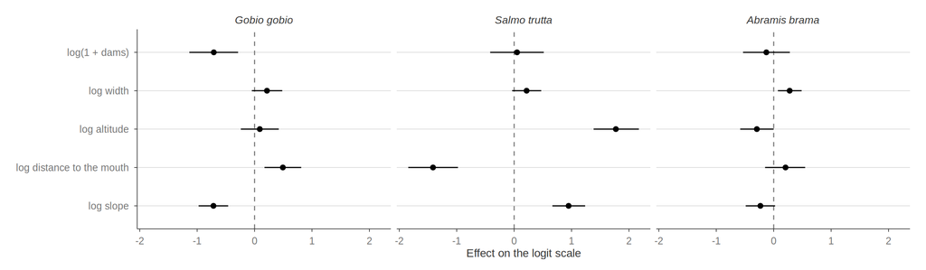

```r
position_label <- c(
  accumulation = "log(1 + dams)", log_width = "log width", log_alt = "log altitude",
  log_dist = "log distance to the mouth", log_slope = "log slope"
)
first_coefficient |>
  filter(term %in% names(position_label)) |>
  mutate(
    term = factor(position_label[term], rev(position_label)),
    species = factor(species, c("Gobio gobio", "Salmo trutta", "Abramis brama"))
  ) |>
  ggplot(aes(estimate, term)) +
  geom_vline(xintercept = 0, linetype = "dashed", color = "grey50") +
  geom_pointrange(aes(xmin = lower, xmax = upper), size = 0.3) +
  facet_wrap(~species, nrow = 1) +
  labs(x = "Effect on the logit scale", y = NULL) +
  theme(strip.text = element_text(face = "italic"))
```

**Note**

We do not include the spatial field in the prediction as it can captures patterns missed by covariates and make the residuals appear better than what is truly captured by the covariates.

```r
map_species <- c("Gobio gobio", "Salmo trutta", "Abramis brama")
distance_term <- c(
  `with distance` = "accumulation + log_width + log_alt + log_dist + log_slope",
  `without distance` = "accumulation + log_width + log_alt + log_slope"
)

# Presence probability at each site predicted by `model` without the local
# variations of the spatial field (field at its mean over the visits),
# averaged over the site effect distribution (50 quantiles of a normal with
# the estimated site variance), then over the visits of the site.
site_probability <- function(model) {
  eta <- model$summary.linear.predictor$mean[seq_len(nrow(visit))]
  field <- as.vector(spatial_A %*% model$summary.random$spatial$mean)
  site_effect <- model$summary.random$site$mean[match(visit$site, model$summary.random$site$ID)]
  site_sd <- 1 / sqrt(model$summary.hyperpar["Precision for site", "mean"])
  covariate_part <- eta - site_effect - field + mean(field)
  visit |>
    mutate(p = rowMeans(plogis(outer(covariate_part, site_sd * qnorm(ppoints(50)), `+`)))) |>
    summarise(p = mean(p), n = n(), .by = sandre_code)
}
species_fit <- tidyr::expand_grid(species = map_species, model = names(distance_term)) |>
  mutate(fit = purrr::map2(species, model, function(s, m) {
    model <- fit_presence_model(s, distance_term[[m]])
    list(prediction = site_probability(model), field = model$summary.random$spatial$mean)
  }))
species_prediction <- species_fit |>
  mutate(prediction = purrr::map(fit, "prediction")) |>
  select(-fit) |>
  tidyr::unnest(prediction)
# Spatial field of the models with distance, at the mesh nodes.
species_field <- species_fit |>
  filter(model == "with distance") |>
  transmute(species, field = purrr::map(fit, "field"))
```

Share of the visits of each site where the species was caught (grey: never caught).

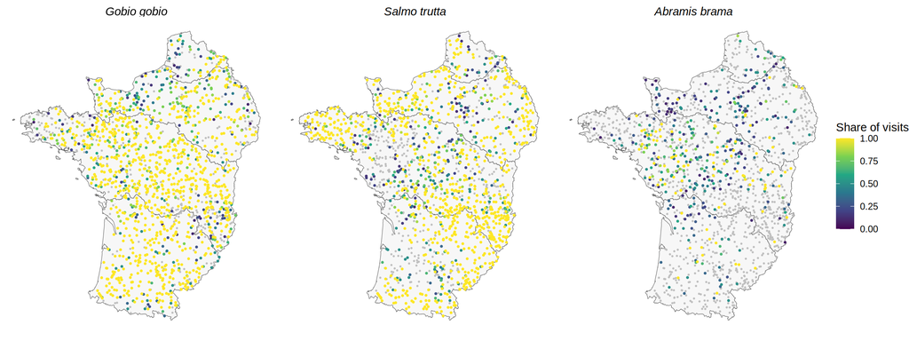

```r
# Observed share of the visits of each site where each species was caught.
species_site <- purrr::map_dfr(map_species, function(species) {
  visit |>
    mutate(present = operation_id %in% presence$operation_id[presence$species_valid == species]) |>
    summarise(
      observed = mean(present), longitude = first(longitude), latitude = first(latitude),
      .by = sandre_code
    ) |>
    mutate(species = species)
}) |>
  mutate(species = factor(species, map_species))

ggplot(species_site, aes(longitude, latitude)) +
  geom_sf(
    data = sf::st_transform(basin_kept, 4326), fill = "grey97",
    color = "grey40", inherit.aes = FALSE
  ) +
  geom_point(data = filter(species_site, observed == 0), color = "grey75", size = 0.3) +
  geom_point(
    data = filter(species_site, observed > 0) |> arrange(observed),
    aes(color = observed), size = 0.6
  ) +
  facet_wrap(~species) +
  scale_color_viridis_c(name = "Share of visits", limits = c(0, 1)) +
  theme_void() +
  theme(strip.text = element_text(face = "italic", size = 11))
```

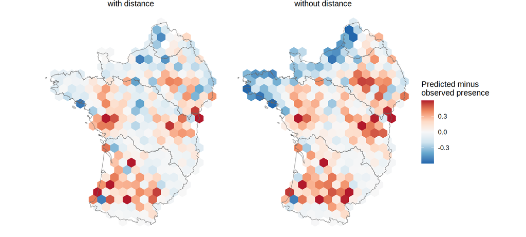

```r
# Hexagons of 40 km over the sites (Lambert-93).
site_hexagon <- distinct(species_site, sandre_code, longitude, latitude) |>
  sf::st_as_sf(coords = c("longitude", "latitude"), crs = 4326) |>
  sf::st_transform(2154)
hexagon <- sf::st_make_grid(site_hexagon, cellsize = 40000, square = FALSE) |>
  sf::st_as_sf() |>
  mutate(hexagon = row_number())
site_hexagon <- tibble(
  sandre_code = site_hexagon$sandre_code,
  hexagon = sapply(sf::st_intersects(site_hexagon, hexagon), `[`, 1)
)

# Predicted minus observed presence of `prediction` (one row per site and
# model, with `p` and the number of visits `n`), averaged over the visits
# in each hexagon.
residual_hexagon <- function(prediction, ...) {
  prediction |>
    inner_join(species_site, by = c("species", "sandre_code")) |>
    inner_join(site_hexagon, by = "sandre_code") |>
    summarise(residual = weighted.mean(p - observed, n), .by = c(hexagon, ...)) |>
    inner_join(hexagon, x = _, by = "hexagon") |>
    sf::st_as_sf()
}
residual_scale <- scale_fill_distiller(
  palette = "RdBu", limits = c(-0.6, 0.6), oob = scales::squish,
  name = "Predicted minus\nobserved presence"
)

species_prediction |>
  mutate(species = factor(species, map_species)) |>
  filter(species == "Salmo trutta") |>
  residual_hexagon(species, model) |>
  ggplot() +
  geom_sf(aes(fill = residual), color = NA) +
  geom_sf(data = sf::st_transform(basin_kept, 2154), fill = NA, color = "grey40") +
  facet_wrap(~model) +
  residual_scale +
  theme_void() +
  theme(strip.text = element_text(size = 11))
```

### Evaluating the first model

To evaluate how the model performs and how it functions we can have a look at the spatial field. The spatial field can capture effect of missing covariates or capture true biogeographical effect. By investigating its patterns, we can understand what the model captures and misses. We plot the spatial random field for our three species.

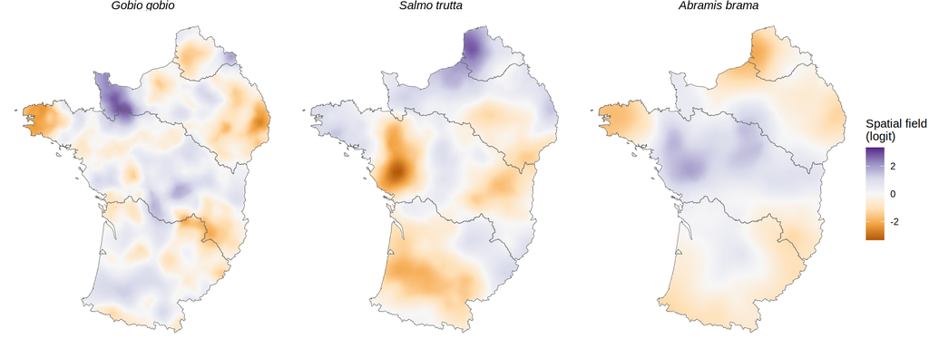

```r
# 5 km grid (Lambert-93, km) over the basins, projected from the mesh.
basin_union <- sf::st_union(sf::st_transform(basin_kept, 2154))
field_grid <- sf::st_make_grid(basin_union, cellsize = 5000, what = "centers")
field_grid <- sf::st_coordinates(field_grid[lengths(sf::st_intersects(field_grid, basin_union)) > 0])
field_A <- INLA::inla.spde.make.A(spatial_mesh, loc = field_grid / 1000)
field_map <- species_field |>
  mutate(value = purrr::map(field, function(field) {
    tibble(
      x = field_grid[, "X"], y = field_grid[, "Y"],
      value = as.vector(field_A %*% field) - mean(as.vector(spatial_A %*% field))
    )
  })) |>
  select(-field) |>
  tidyr::unnest(value) |>
  mutate(species = factor(species, map_species))
field_limit <- max(abs(field_map$value))
ggplot(field_map) +
  geom_raster(aes(x, y, fill = value)) +
  geom_sf(data = sf::st_transform(basin_kept, 2154), fill = NA, color = "grey40") +
  facet_wrap(~species) +
  scale_fill_distiller(
    palette = "PuOr", direction = 1, limits = c(-field_limit, field_limit),
    name = "Spatial field\n(logit)"
  ) +
  theme_void() +
  theme(strip.text = element_text(face = "italic", size = 11))
```

Field capture regional patterns for the bream and the brown trout potentially reflecting dispersal history, connection large rivers, etc. For the gudgeon, the field seems to reflect part of remaining altitude effect, as it takes negative values at high altitude. To check for that we add a quadratic term to the model and see how it changes its performance by looking at its WAIC and residuals in space.

### Linear or quadratic altitude?

We fit a model for the gudgeon with a quadratic altitude term and compare its residuals with the previous model, as well as its WAIC, to see if it performs any better. We also have a look at how this adding this control changes the dam effect, as this ultimately what we want to capture, and so remove any bias that can affect it.

```r
altitude_term <- c(
  linear = "accumulation + log_width + log_alt + log_dist + log_slope",
  quadratic = "accumulation + log_width + log_alt + I(log_alt^2) + log_dist + log_slope"
)
altitude_model <- lapply(altitude_term, \(term) fit_presence_model("Gobio gobio", term))
altitude_fit <- purrr::imap_dfr(altitude_model, \(m, shape) tibble(
  shape,
  dam_effect = sprintf(
    "%.2f (%.2f, %.2f)", m$summary.fixed["accumulation", "mean"],
    m$summary.fixed["accumulation", "0.025quant"], m$summary.fixed["accumulation", "0.975quant"]
  ),
  waic = m$waic$waic, mlik = m$mlik[1, 1]
))
altitude_site <- purrr::imap_dfr(
  altitude_model, \(m, shape) mutate(site_probability(m), shape = shape, species = "Gobio gobio")
)
rm(altitude_model)
```

Predicted minus observed presence of the gudgeon models with a linear and with a quadratic log altitude, averaged over the visits in hexagons of 40 km (as in the residual map above).

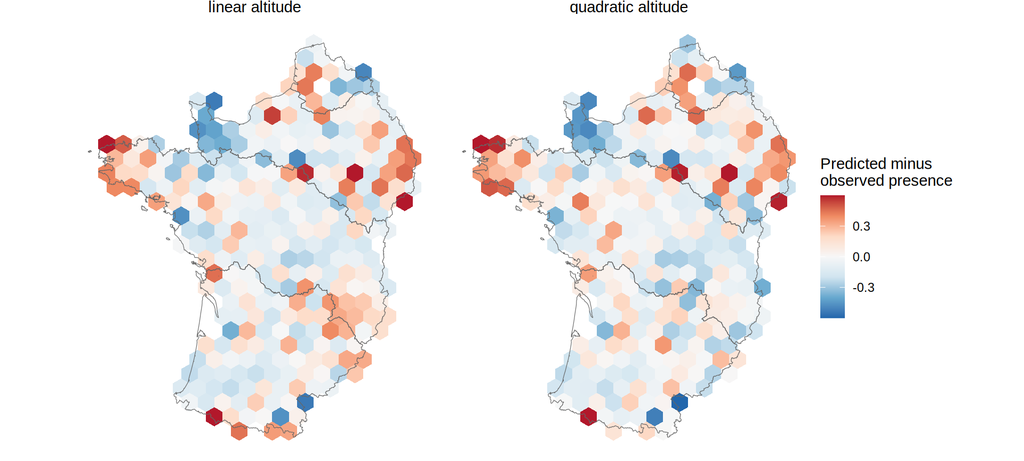

```r
altitude_site |>
  mutate(
    species = factor(species, map_species),
    shape = factor(paste(shape, "altitude"), c("linear altitude", "quadratic altitude"))
  ) |>
  residual_hexagon(shape) |>
  ggplot() +
  geom_sf(aes(fill = residual), color = NA) +
  geom_sf(data = sf::st_transform(basin_kept, 2154), fill = NA, color = "grey40") +
  facet_wrap(~shape) +
  residual_scale +
  theme_void() +
  theme(strip.text = element_text(size = 11))
```

WAIC and log marginal likelihood of the linear altitude model against the quadratic one (WAIC: positive, worse than the quadratic; log marginal likelihood: negative, worse than the quadratic), and dam effect.

```r
altitude_fit |>
  mutate(
    waic_vs_quadratic = round(waic - waic[shape == "quadratic"], 1),
    mlik_vs_quadratic = round(mlik - mlik[shape == "quadratic"], 1)
  ) |>
  select(shape, dam_effect, waic_vs_quadratic, mlik_vs_quadratic) |>
  knitr::kable()
```

| shape | dam_effect | waic_vs_quadratic | mlik_vs_quadratic |
| --- | --- | --- | --- |
| linear | -0.71 (-1.14, -0.29) | 23.1 | -11.1 |
| quadratic | -0.32 (-0.75, 0.10) | 0.0 | 0.0 |

**Results:** on the map, the linear model predicts too many gudgeons in the uplands (the eastern Massif Central and the foothills of the Pyrenees); the quadratic model removes most of this excess. The quadratic term improves the gudgeon’s WAIC by 23 and its log marginal likelihood by 11, and halves its dam effect: with a linear altitude, the dam count takes over the drop the line misses.

*To discuss:* keep the quadratic term for all species, or only where it improves the fit.

```r
effort_term <- paste(
  "district + protocol + log_surface +",
  "f(site, model = 'iid') + f(year, model = 'iid')"
)

# INLA model of `response` on `term` + effort, gc() after each fit
# (memory).
fit_inla <- function(data, response, term, family, ...) {
  model <- INLA::inla(
    as.formula(paste(response, "~", term, "+", effort_term)),
    family = family, data = data, num.threads = 4,
    control.compute = list(config = FALSE, waic = TRUE), ...
  )
  gc()
  model
}

# Effect of log(1 + dams) in the presence model of `species` on `term`,
# with the WAIC.
fit_presence <- function(species, term) {
  model <- fit_presence_model(species, term)
  effect <- model$summary.fixed["accumulation", ]
  tibble(
    species = species,
    presences = sum(visit$operation_id %in% presence$operation_id[presence$species_valid == species]),
    estimate = effect$mean, lower = effect$`0.025quant`, upper = effect$`0.975quant`,
    waic = model$waic$waic
  )
}

species_group <- presence |>
  distinct(species = species_valid) |>
  left_join(tar_read(species_traits) |> select(species, is_native), by = "species") |>
  mutate(group = case_when(
    species %in% migratory ~ "migratory",
    !is_native ~ "non-native",
    .default = "native resident"
  ))

species_common <- presence |>
  inner_join(distinct(visit, operation_id, sandre_code), by = "operation_id") |>
  distinct(species_valid, sandre_code) |>
  count(species_valid) |>
  filter(n >= species_min_sites) |>
  pull(species_valid)

species_model <- c(
  "Anguilla anguilla", "Salmo trutta", "Squalius cephalus", "Gobio gobio", "Barbus barbus"
)
presence_effect <- species_model |>
  lapply(fit_presence, term = paste("accumulation +", control_term)) |>
  bind_rows() |>
  left_join(species_group |> select(species, group), by = "species")
```

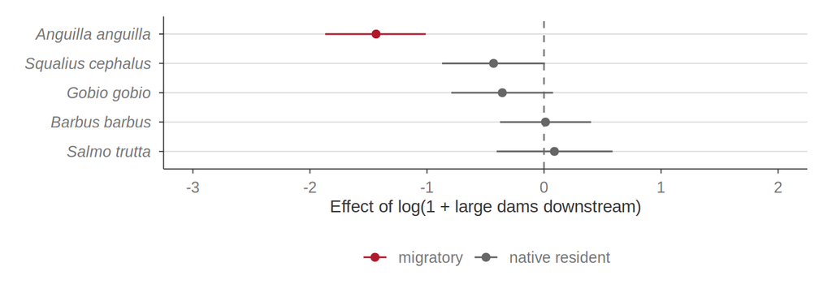

```r
group_color <- c(
  migratory = "#B2182B", `non-native` = "#E69F00", `native resident` = "grey40"
)
presence_effect |>
  mutate(species = reorder(species, -estimate)) |>
  ggplot(aes(estimate, species, color = group)) +
  geom_vline(xintercept = 0, linetype = "dashed", color = "grey50") +
  geom_pointrange(aes(xmin = lower, xmax = upper), size = 0.3) +
  scale_color_manual(values = group_color) +
  coord_cartesian(xlim = c(-3, 2)) +
  labs(x = "Effect of log(1 + large dams downstream)", y = NULL, color = NULL) +
  theme(axis.text.y = element_text(face = "italic"))
```

### Choice of the position controls

Dams are not spread evenly along the rivers: they are built where there is a drop, in the uplands. Below 100 m few sites have a large dam downstream; above 300 m almost all do, and above 800 m all of them (table below). Species ranges also change with altitude, and not along a straight line: many lowland species are frequent up to about 300 m, then drop out quickly. With a linear altitude term, or with the D11 continuum axes (PC1, river size; PC2, altitude and distance to the mouth), which are linear combinations of these variables, the model cannot follow this drop. The dam count, high exactly where the drop happens, then takes it over, and the dam effects are overestimated. A quadratic term in log altitude lets the presence curve bend down.

The position controls are therefore the log river width (river size: PC1 is mostly width, correlation 0.94), the log altitude with its square, and the log distance to the mouth. All describe the geography of the site, which the dams do not change. Above about 500 m, there are almost no sites without a dam to compare with: there, the dam effect rests on the shape of the altitude curve.

Other descriptors of the river size, such as the Strahler order, are not included: they carry the same information as the width (see the VIFs above).

The VIFs only look at the covariates, not at the random effects and the spatial field, which can compete with covariates that also vary smoothly over space (dams and altitude do). The posterior correlations between the coefficients of the fitted model, field included, show directly whether the data separate the dam effect from the position effects: a correlation close to $\pm 1$ between two coefficients means that the data can raise one and lower the other with almost no loss of fit. Below, for the eel and the gudgeon (presence models with the chosen controls).

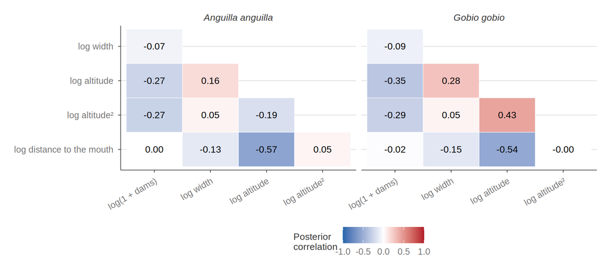

```r
coefficient_label <- c(
  accumulation = "log(1 + dams)", log_width = "log width", log_alt = "log altitude",
  `I(log_alt^2)` = "log altitude²", log_dist = "log distance to the mouth"
)
posterior_correlation <- purrr::map_dfr(c("Anguilla anguilla", "Gobio gobio"), function(species) {
  model <- fit_presence_model(species, paste("accumulation +", control_term))
  correlation <- model$misc$lincomb.derived.correlation.matrix
  rownames(correlation) <- colnames(correlation) <- rownames(model$summary.fixed)
  correlation <- correlation[names(coefficient_label), names(coefficient_label)]
  as_tibble(correlation, rownames = "x") |>
    tidyr::pivot_longer(-x, names_to = "y", values_to = "rho") |>
    mutate(species = species)
})
posterior_correlation |>
  mutate(
    x = factor(coefficient_label[x], coefficient_label),
    y = factor(coefficient_label[y], rev(coefficient_label))
  ) |>
  filter(as.integer(x) < length(coefficient_label) + 1 - as.integer(y)) |>
  ggplot(aes(x, y, fill = rho)) +
  geom_tile(color = "white") +
  geom_text(aes(label = sprintf("%.2f", rho)), size = 3.5) +
  facet_wrap(~species) +
  scale_fill_gradient2(low = "#2166AC", high = "#B2182B", limits = c(-1, 1)) +
  labs(x = NULL, y = NULL, fill = "Posterior\ncorrelation") +
  theme(
    axis.text.x = element_text(angle = 30, hjust = 1), panel.grid = element_blank(),
    strip.text = element_text(face = "italic")
  )
```

**Results:** in the fitted models, the dam effect is only weakly correlated with the position effects: about -0.27 (eel) and -0.35 (gudgeon) with the altitude, and almost none with the distance to the mouth or the width. The strongest correlation, between the altitude and the distance to the mouth (about -0.55), stays well away from $\pm 1$. Even with the spatial field, the data separate the dam effect from the position of the sites.

```r
altitude_band <- function(altitude) {
  cut(
    altitude, c(-Inf, 100, 300, 500, 800, Inf),
    c("< 100 m", "100-300 m", "300-500 m", "500-800 m", "> 800 m")
  )
}
visit |>
  mutate(altitude_band = altitude_band(exp(log_altitude))) |>
  summarise(
    visits = n(), with_dam = round(mean(dams > 0), 2), mean_dams = round(mean(dams), 1),
    .by = altitude_band
  ) |>
  arrange(altitude_band)
```

```
  altitude_band visits with_dam mean_dams
1       < 100 m   3167     0.18       0.2
2     100-300 m   1858     0.36       0.6
3     300-500 m    377     0.79       2.4
4     500-800 m    273     0.99       3.9
5       > 800 m    254     1.00       3.8
```

Share of the visits where each species is caught, by altitude band, at sites with and without a large dam downstream (bands with at least 20 visits).

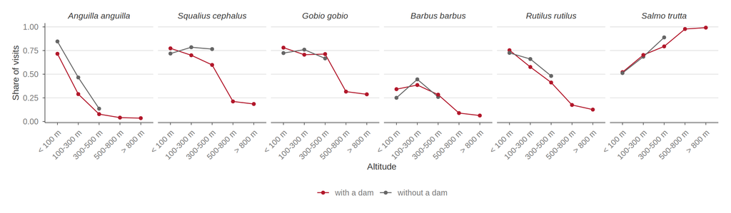

```r
altitude_species <- c(
  "Anguilla anguilla", "Squalius cephalus", "Gobio gobio", "Barbus barbus",
  "Rutilus rutilus", "Salmo trutta"
)
visit |>
  transmute(
    operation_id,
    altitude_band = altitude_band(exp(log_altitude)),
    dam = if_else(dams > 0, "with a dam", "without a dam")
  ) |>
  tidyr::crossing(species = altitude_species) |>
  left_join(
    presence |> transmute(operation_id, species = species_valid, present = 1),
    by = c("operation_id", "species")
  ) |>
  summarise(
    occurrence = mean(coalesce(present, 0)), visits = n(),
    .by = c(species, altitude_band, dam)
  ) |>
  filter(visits >= 20) |>
  mutate(species = factor(species, altitude_species)) |>
  ggplot(aes(altitude_band, occurrence, color = dam, group = dam)) +
  geom_line() +
  geom_point() +
  facet_wrap(~species, nrow = 1) +
  scale_color_manual(values = c(`with a dam` = "#B2182B", `without a dam` = "grey40")) +
  labs(x = "Altitude", y = "Share of visits", color = NULL) +
  theme(
    axis.text.x = element_text(angle = 45, hjust = 1),
    strip.text = element_text(face = "italic")
  )
```

The presence models are refitted with two other sets of position controls: the D11 axes (PC1 + PC2) and the same variables with a linear altitude. For each set, the number of species credibly less frequent with dams, the median dam effect, and the WAIC compared with the chosen controls (per species; negative: the chosen controls fit better).

```r
control_set <- c(
  `D11 axes (PC1 + PC2)` = "PC1 + PC2",
  `width + altitude + distance, linear` = "log_width + log_alt + log_dist"
)
control_effect <- tidyr::expand_grid(species = species_model, control = names(control_set)) |>
  purrr::pmap(\(species, control) {
    fit_presence(species, paste("accumulation +", control_set[[control]])) |>
      mutate(control = control)
  }) |>
  bind_rows() |>
  bind_rows(mutate(presence_effect, control = "width + quadratic altitude + distance")) |>
  select(-group) |>
  left_join(species_group |> select(species, group), by = "species")
```

```r
control_effect |>
  left_join(
    presence_effect |> select(species, waic_chosen = waic),
    by = "species"
  ) |>
  summarise(
    negative = sum(upper < 0), positive = sum(lower > 0),
    median_effect = round(median(estimate), 2),
    median_waic_vs_chosen = round(median(waic_chosen - waic), 1),
    chosen_fits_better = sum(waic_chosen < waic - 2),
    .by = control
  )
```

```
# A tibble: 3 × 6
  control                  negative positive median_effect median_waic_vs_chosen
  <chr>                       <int>    <int>         <dbl>                 <dbl>
1 D11 axes (PC1 + PC2)            3        0         -0.66                 -26.3
2 width + altitude + dist…        3        0         -0.73                 -24.1
3 width + quadratic altit…        1        0         -0.36                   0
# ℹ 1 more variable: chosen_fits_better <int>
```

Effect of log(1 + dams) per species with the D11 axes (x) and with the chosen controls (y); filled points: credible with the chosen controls.

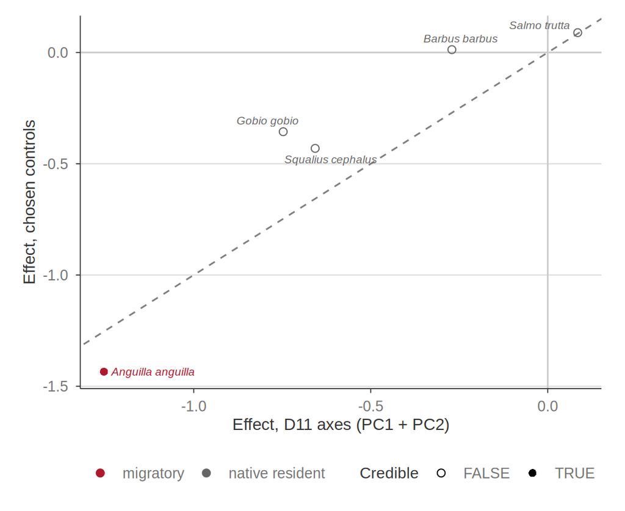

```r
control_effect |>
  filter(control == "D11 axes (PC1 + PC2)") |>
  select(species, group, estimate_pc = estimate) |>
  left_join(presence_effect |> select(species, estimate, lower, upper), by = "species") |>
  mutate(credible = upper < 0 | lower > 0) |>
  ggplot(aes(estimate_pc, estimate, color = group)) +
  geom_abline(linetype = "dashed", color = "grey50") +
  geom_hline(yintercept = 0, color = "grey80") +
  geom_vline(xintercept = 0, color = "grey80") +
  geom_point(aes(shape = credible), size = 2) +
  ggrepel::geom_text_repel(aes(label = species), size = 2.5, fontface = "italic", show.legend = FALSE) +
  scale_color_manual(values = group_color) +
  scale_shape_manual(values = c(`TRUE` = 16, `FALSE` = 1)) +
  labs(x = "Effect, D11 axes (PC1 + PC2)", y = "Effect, chosen controls", color = NULL, shape = "Credible")
```

## Impact on food web structure

Local food webs of the visits (D11 `foodweb_structure`): fish richness $S$ (number of fish species caught), trophic length $L$ (maximum prey-averaged trophic level) and diet overlap $O$ between fish species (mean Jaccard similarity of prey sets over pairs of fish consumers). Visits with fewer than 3 fish species are left out (too few species to reconstruct a network). Webs without a piscivore have a trophic length of about 3 (a fish eating invertebrates), apart from the other webs: trophic length is modelled in two parts, the presence of a piscivore $P$ and the trophic length of the webs with a piscivore.

Dam metric: $D_i$, the number of large dams (ROE obstacles with a drop height $\geq$ 5 m, on the AMOBIO river network) between the site of visit $i$ and the sea. Position controls, as in the presence models: the log river width $W_i$, the log altitude $H_i$ (with a quadratic term) and the log distance to the mouth $M_i$. Sampling effort: the fishing protocol and the fished surface $A_i$. For visit $i$ at site $s$ and in year $t$, the linear predictor is

$$\eta_i = \beta_0 + \beta_D \log(1 + D_i) + \beta_W W_i
+ \beta_H H_i + \beta_{H^2} H_i^2 + \beta_M M_i
+ \alpha_{\mathrm{district}(i)} + \gamma_{\mathrm{protocol}(i)}
+ \beta_A \log A_i + u_s + v_t,$$

$$u_s \sim \mathcal{N}(0, \sigma_u^2), \quad
v_t \sim \mathcal{N}(0, \sigma_v^2),$$

with its own parameters for each response:

$$\begin{aligned}
S_i &\sim \mathrm{Poisson}(\lambda_i), & \log \lambda_i &= \eta_i, \\
P_i &\sim \mathrm{Bernoulli}(\pi_i), & \mathrm{logit}\, \pi_i &= \eta_i + \beta_S \log S_i, \\
L_i \mid P_i = 1 &\sim \mathcal{N}(\mu_i, \sigma^2), & \mu_i &= \eta_i + \beta_S \log S_i, \\
O_i &\sim \mathcal{N}(\mu_i, \sigma^2), & \mu_i &= \eta_i + \beta_S \log S_i.
\end{aligned}$$

The structure metrics ($P$, $L$, $O$) are fitted without ($\beta_S = 0$) and with log fish richness (centred) as a covariate: $\beta_D$ is then the dam effect at equal richness.

```r
foodweb_visit <- visit |>
  inner_join(
    tar_read(foodweb_structure) |>
      distinct(operation_id, .keep_all = TRUE) |>
      select(operation_id, trophic_length, frac_piscivorous, fish_diet_overlap),
    by = "operation_id"
  ) |>
  left_join(count(presence, operation_id, name = "fish_richness"), by = "operation_id") |>
  filter(fish_richness >= 3) |>
  mutate(
    accumulation = log1p(dams),
    log_richness = log(fish_richness) - mean(log(fish_richness)),
    piscivore = as.numeric(frac_piscivorous > 0)
  )
c(visits = nrow(foodweb_visit), piscivore = sum(foodweb_visit$piscivore))
```

```
   visits piscivore
     5665      5451
```

```r
foodweb_response <- c(
  fish_richness = "S: fish richness",
  piscivore = "TL, part 1:\npiscivore present",
  trophic_length = "TL, part 2: trophic length\n(webs with a piscivore)",
  fish_diet_overlap = "O: diet overlap (fish)"
)
foodweb_family <- c(
  fish_richness = "poisson", piscivore = "binomial",
  trophic_length = "gaussian", fish_diet_overlap = "gaussian"
)

# Effects of the `dam` terms, the position controls (and log richness) on
# `response` in `data`, with the log marginal likelihood.
fit_foodweb <- function(data, response, family, richness, dam) {
  term <- paste(c(
    dam, if (richness) "log_richness", control_term, "district",
    "protocol + log_surface",
    "f(site, model = 'iid') + f(year, model = 'iid')"
  ), collapse = " + ")
  model <- INLA::inla(
    as.formula(paste(response, "~", term)),
    family = family, data = data, num.threads = 4,
    control.compute = list(config = FALSE)
  )
  effect <- model$summary.fixed[c(all.vars(as.formula(paste("~", dam))), control_coef, if (richness) "log_richness"), ]
  gc()
  tibble(
    response = response, family = family, richness = richness,
    term = rownames(effect), mean = effect$mean, sd = effect$sd,
    lower = effect$`0.025quant`, upper = effect$`0.975quant`,
    mlik = model$mlik[1, 1]
  )
}

foodweb_fit <- tidyr::expand_grid(
  response = names(foodweb_response), richness = c(FALSE, TRUE)
) |>
  filter(!(response == "fish_richness" & richness)) |>
  purrr::pmap(\(response, richness) fit_foodweb(
    if (response == "trophic_length") filter(foodweb_visit, piscivore == 1) else foodweb_visit,
    response, foodweb_family[[response]], richness, "accumulation"
  ))
foodweb_effect <- bind_rows(foodweb_fit) |>
  mutate(response = factor(response, names(foodweb_response), foodweb_response))
```

Effects of log(1 + dams) and of the position controls (posterior mean and 95% credible interval; log scale for fish richness, logit scale for the presence of a piscivore), without and with log fish richness as a covariate.

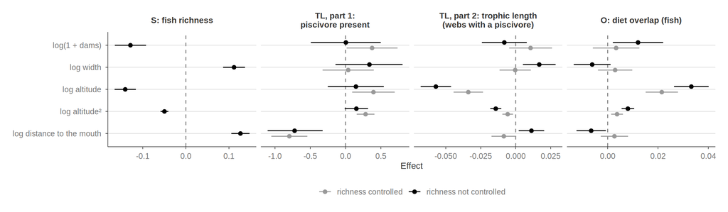

```r
foodweb_effect |>
  filter(term != "log_richness") |>
  mutate(
    model = if_else(richness, "richness controlled", "richness not controlled"),
    term = factor(
      term, rev(c("accumulation", control_coef)),
      rev(c("log(1 + dams)", "log width", "log altitude", "log altitude²", "log distance to the mouth"))
    )
  ) |>
  ggplot(aes(mean, term, color = model)) +
  geom_vline(xintercept = 0, linetype = "dashed", color = "grey50") +
  geom_pointrange(
    aes(xmin = lower, xmax = upper),
    size = 0.3,
    position = position_dodge(width = 0.5)
  ) +
  facet_wrap(~response, nrow = 1, scales = "free_x") +
  scale_color_manual(values = c(`richness not controlled` = "black", `richness controlled` = "grey60")) +
  labs(x = "Effect", y = NULL, color = NULL)
```

### Size structure of the food webs

The food webs are built from size classes: each species is split into classes of body length that set its diet (ontogenetic shifts), so the size of the individuals caught shapes the web. Two measures of size structure, from the individual lengths $L$ (cm) of the visits with at least 3 fish species, each fitted with the model above (Gaussian):

1. Community mean size. The mean log length over the $N_i$ individuals of visit $i$, $\bar{x}_i = \frac{1}{N_i} \sum_k \log L_k$, is split into a species turnover part, with each species $s$ at its mean log length over all visits $m_s$, $\tilde{x}_i = \sum_s \frac{n_{is}}{N_i} m_s$ ($n_{is}$ individuals of species $s$), and a within-species part, $\bar{x}_i - \tilde{x}_i$ (Lepš et al. 2011).
2. Path from dams to trophic length (webs with a piscivore and at least one fish-eating individual). The top predator size is the log length of the largest individual above the length at which its species eats fish (diet stages). Dams act on the top predator size and on fish richness (coefficients $a$), which both act on trophic length (coefficients $b$, fitted together with the direct effect $c'$ of the dams):
   $$\begin{aligned}
   \log L^{\mathrm{top}}_i &= \ldots + a_1 \log(1 + D_i), &
   \log S_i &= \ldots + a_2 \log(1 + D_i), \\
   \mathrm{TL}_i &= \ldots + c' \log(1 + D_i) + b_1 \log L^{\mathrm{top}}_i + b_2 \log S_i,
   \end{aligned}$$
   with the indirect effects $a_1 b_1$ and $a_2 b_2$ (product of the posterior marginals, 100,000 draws).

```r
size_individual <- tar_read(size_year_filtered) |>
  filter(
    survey == "river", operation_id %in% foodweb_visit$operation_id,
    !is.na(length), length > 0
  ) |>
  select(operation_id, species = species_valid, length)
fish_eating_length <- tar_read(diet) |>
  filter(fish == 1) |>
  summarise(fish_from = min(length_min), .by = species)

size_visit <- size_individual |>
  mutate(log_length = log(length)) |>
  mutate(species_log_length = mean(log_length), .by = species) |>
  summarise(
    total = mean(log_length),
    turnover = mean(species_log_length),
    .by = operation_id
  ) |>
  mutate(intraspecific = total - turnover) |>
  left_join(
    size_individual |>
      inner_join(fish_eating_length, by = "species") |>
      filter(length >= fish_from) |>
      summarise(log_top_predator = log(max(length)), .by = operation_id),
    by = "operation_id"
  )
foodweb_size <- inner_join(foodweb_visit, size_visit, by = "operation_id")
c(visits = nrow(foodweb_size), top_predator = sum(!is.na(foodweb_size$log_top_predator)))
```

```
      visits top_predator
        5665         5459
```

```r
set.seed(1)
# Effect of log(1 + dams) on a size measure.
fit_size <- function(data, response) {
  fit_foodweb(data, response, "gaussian", FALSE, "accumulation") |>
    filter(term == "accumulation")
}
size_effect <- bind_rows(
  lapply(c("total", "turnover", "intraspecific"), \(x) fit_size(foodweb_size, x))
)

path_visit <- filter(foodweb_size, piscivore == 1, !is.na(log_top_predator))
path_a <- bind_rows(
  fit_size(path_visit, "log_top_predator"),
  fit_size(path_visit, "log_richness")
)
path_total <- fit_size(path_visit, "trophic_length")
path_b <- fit_foodweb(
  path_visit, "trophic_length", "gaussian", FALSE,
  "accumulation + log_top_predator + log_richness"
)
path_draw <- \(x) rnorm(1e5, x$mean, x$sd)
path_indirect <- tibble(
  path = c("log_top_predator", "log_richness"),
  draw = list(
    path_draw(path_a[1, ]) * path_draw(filter(path_b, term == "log_top_predator")),
    path_draw(path_a[2, ]) * path_draw(filter(path_b, term == "log_richness"))
  )
) |>
  mutate(
    mean = sapply(draw, mean),
    lower = sapply(draw, quantile, 0.025), upper = sapply(draw, quantile, 0.975)
  ) |>
  select(-draw)
nrow(path_visit)
```

```
[1] 5438
```

Effects of log(1 + dams) on the community mean log length and its two parts (posterior mean and 95% credible interval).

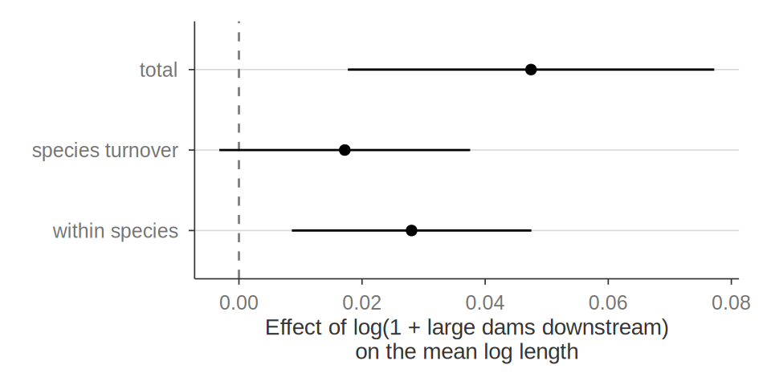

```r
size_effect |>
  mutate(response = factor(
    response, rev(c("total", "turnover", "intraspecific")),
    rev(c("total", "species turnover", "within species"))
  )) |>
  ggplot(aes(mean, response)) +
  geom_vline(xintercept = 0, linetype = "dashed", color = "grey50") +
  geom_pointrange(aes(xmin = lower, xmax = upper), size = 0.3) +
  labs(x = "Effect of log(1 + large dams downstream)
on the mean log length", y = NULL)
```

Path from the number of dams to trophic length (webs with a piscivore): posterior mean of each coefficient (95% credible interval), solid when the interval excludes 0; indirect effects ($a \times b$), direct and total effect below.

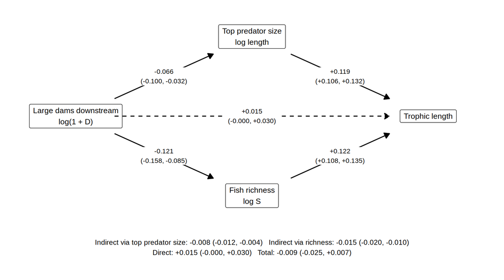

```r
path_label <- \(x) sprintf("%+.3f\n(%+.3f, %+.3f)", x$mean, x$lower, x$upper)
path_node <- tibble(
  node = c("Large dams downstream\nlog(1 + D)", "Top predator size\nlog length", "Fish richness\nlog S", "Trophic length"),
  x = c(0, 1, 1, 2), y = c(0, 1, -1, 0)
)
path_edge <- bind_rows(
  path_a |> mutate(x = 0, y = 0, xend = 1, yend = c(1, -1)),
  path_b |> filter(term %in% c("log_top_predator", "log_richness")) |>
    mutate(x = 1, y = c(1, -1), xend = 2, yend = 0),
  path_b |> filter(term == "accumulation") |> mutate(x = 0, y = 0, xend = 2, yend = 0)
) |>
  mutate(
    credible = lower > 0 | upper < 0,
    label = path_label(pick(mean, lower, upper)),
    # Arrows stop at the box edges.
    x_start = x + 0.22 * sign(xend - x), x_end = xend - 0.22 * sign(xend - x),
    y_start = y + 0.22 * (yend - y) / abs(xend - x), y_end = yend - 0.22 * (yend - y) / abs(xend - x)
  )
path_summary <- sprintf(
  "Indirect via top predator size: %s   Indirect via richness: %s\nDirect: %s   Total: %s",
  sub("\n", " ", path_label(path_indirect[1, ])), sub("\n", " ", path_label(path_indirect[2, ])),
  sub("\n", " ", path_label(filter(path_b, term == "accumulation"))), sub("\n", " ", path_label(path_total))
)
ggplot() +
  geom_segment(
    data = path_edge,
    aes(x = x_start, y = y_start, xend = x_end, yend = y_end, linetype = credible),
    arrow = arrow(length = unit(0.25, "cm"), type = "closed"), linewidth = 0.6
  ) +
  geom_label(
    data = path_edge,
    aes(x = (x + xend) / 2, y = (y + yend) / 2, label = label),
    size = 3, label.size = 0, fill = "white"
  ) +
  geom_label(data = path_node, aes(x, y, label = node), size = 3.5, label.padding = unit(0.4, "lines")) +
  annotate("text", x = 1, y = -1.65, label = path_summary, size = 3.2) +
  scale_linetype_manual(values = c(`TRUE` = "solid", `FALSE` = "dashed"), guide = "none") +
  coord_cartesian(xlim = c(-0.3, 2.3), ylim = c(-1.9, 1.3)) +
  theme_void()
```

**Results:** with more dams, the fish caught are slightly larger on average, in similar parts because individuals are larger within species and because small species drop out. At the top of the web it is the reverse: the largest fish-eating fish is smaller. Fewer species and smaller top predators both go with shorter chains, but these indirect paths are small and offset by a slightly positive direct effect of the dams, so the total dam effect on trophic length is not credible.

### Identity of the top predator

Species of the top predator (the largest fish-eating individual) in the webs of the path analysis, by number of large dams downstream. The models of top predator size and trophic length above are refitted with the presence of the eel as a covariate, then with an interaction between the dams and eel presence: one dam slope for the webs without eel ($\log(1 + D_i)(1 - E_i)$) and one for the webs with eel ($\log(1 + D_i) E_i$), with $E_i$ the eel presence (both slopes in one model, with the same controls). The largest eel is also compared between dam classes.

```r
top_predator <- size_individual |>
  inner_join(fish_eating_length, by = "species") |>
  filter(length >= fish_from) |>
  slice_max(length, n = 1, with_ties = FALSE, by = operation_id) |>
  select(operation_id, top_species = species, top_length = length)
eel_visit <- path_visit |>
  inner_join(top_predator, by = "operation_id") |>
  mutate(
    eel = as.numeric(operation_id %in% presence$operation_id[presence$species_valid == "Anguilla anguilla"]),
    dam_class = cut(dams, c(-Inf, 0, 1, 3, Inf), c("0 dams", "1 dam", "2-3 dams", "4+ dams")),
    accumulation_without_eel = accumulation * (1 - eel),
    accumulation_with_eel = accumulation * eel
  )
eel_model <- c(
  `all webs` = "accumulation", `all webs, + eel presence` = "accumulation + eel",
  `dams x eel` = "eel + accumulation_without_eel + accumulation_with_eel"
)
eel_effect <- tidyr::expand_grid(response = c("log_top_predator", "trophic_length"), model = names(eel_model)) |>
  purrr::pmap(\(response, model) fit_foodweb(eel_visit, response, "gaussian", FALSE, eel_model[[model]]) |>
    mutate(model = model)) |>
  bind_rows() |>
  filter(startsWith(term, "accumulation"))
eel_largest <- size_individual |>
  filter(species == "Anguilla anguilla") |>
  summarise(eel_largest = max(length), .by = operation_id) |>
  inner_join(eel_visit, by = "operation_id") |>
  summarise(
    webs = n(), eel_largest = median(eel_largest), top_is_eel = mean(top_species == "Anguilla anguilla"),
    .by = dam_class
  ) |>
  arrange(dam_class)
c(webs = nrow(eel_visit), without_eel = sum(eel_visit$eel == 0))
```

```
       webs without_eel
       5438        2065
```

```r
eel_largest
```

```
  dam_class webs eel_largest top_is_eel
1    0 dams 2743       60.70  0.8034998
2     1 dam  502       59.00  0.7988048
3  2-3 dams  110       56.05  0.6545455
4   4+ dams   18       13.20  0.2222222
```

```r
eel_visit |>
  summarise(top_length = median(top_length), .by = top_species) |>
  filter(top_species %in% c("Anguilla anguilla", "Salmo trutta"))
```

```
        top_species top_length
1      Salmo trutta       27.5
2 Anguilla anguilla       62.4
```

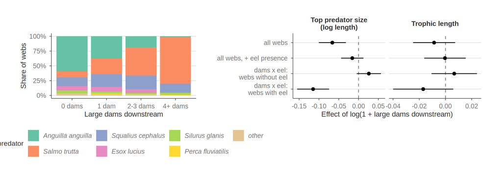

```r
top_main <- eel_visit |>
  count(top_species) |>
  slice_max(n, n = 6) |>
  pull(top_species)
top_share <- eel_visit |>
  mutate(top_species = factor(if_else(top_species %in% top_main, top_species, "other"), c(top_main, "other"))) |>
  count(dam_class, top_species) |>
  mutate(share = n / sum(n), .by = dam_class)
top_share_plot <- ggplot(top_share, aes(dam_class, share, fill = top_species)) +
  geom_col() +
  scale_fill_brewer(palette = "Set2") +
  scale_y_continuous(labels = scales::percent) +
  labs(x = "Large dams downstream", y = "Share of webs", fill = "Top predator") +
  theme(legend.text = element_text(face = "italic"))
eel_effect_plot <- eel_effect |>
  mutate(
    response = factor(response, c("log_top_predator", "trophic_length"), c("Top predator size\n(log length)", "Trophic length")),
    model = factor(
      case_when(
        term == "accumulation_without_eel" ~ "dams x eel:\nwebs without eel",
        term == "accumulation_with_eel" ~ "dams x eel:\nwebs with eel",
        .default = model
      ),
      rev(c("all webs", "all webs, + eel presence", "dams x eel:\nwebs without eel", "dams x eel:\nwebs with eel"))
    )
  ) |>
  ggplot(aes(mean, model)) +
  geom_vline(xintercept = 0, linetype = "dashed", color = "grey50") +
  geom_pointrange(aes(xmin = lower, xmax = upper), size = 0.3) +
  facet_wrap(~response, scales = "free_x") +
  labs(x = "Effect of log(1 + large dams downstream)", y = NULL)
patchwork::wrap_plots(top_share_plot, eel_effect_plot, widths = c(1, 1.3))
```

**Results:** without dams, the top predator is usually the eel; with several dams, it is usually brown trout, a much smaller fish. Where eels remain above dams, the largest one is also smaller. The eel explains why top predators shrink with dams: in webs without eel, dams do not change the size of the top predator, and the effect disappears once eel presence is accounted for. None of these models shows a credible dam effect on trophic length.

### Distance decay of the dam effect

Do nearby dams weigh more than distant ones? Each large dam $j$ downstream of the site of visit $i$ is weighted by its river distance $d_{ij}$, with a decay length $\lambda$:

$$\mathrm{impact}_i(\lambda) = \sum_{j \,\in\, \text{dams downstream of } i} e^{-d_{ij} / \lambda},$$

which enters the models as $\log(1 + \mathrm{impact}_i)$ instead of $\log(1 + D_i)$ ($\lambda \to \infty$ gives back $D_i$). The models (without richness as a covariate) are fitted for $\lambda$ from 5 km to infinity and compared by their log marginal likelihood.

```r
dam_distance <- operation_dam |>
  filter(position == "upstream") |>
  transmute(operation_id, distance_km = river_dist_m / 1000)
decay_length <- c(5, 10, 25, 50, 100, 200, 500, 1000, Inf)

dam_decay <- tidyr::expand_grid(lambda = decay_length, response = names(foodweb_response)) |>
  mutate(effect = purrr::map2(lambda, response, function(lambda, response) {
    data <- foodweb_visit |>
      left_join(
        dam_distance |> summarise(impact = sum(exp(-distance_km / lambda)), .by = operation_id),
        by = "operation_id"
      ) |>
      mutate(impact = log1p(coalesce(impact, 0)))
    if (response == "trophic_length") data <- filter(data, piscivore == 1)
    fit_foodweb(data, response, foodweb_family[[response]], FALSE, "impact") |>
      filter(term == "impact") |>
      select(mean, lower, upper, mlik)
  })) |>
  tidyr::unnest(effect) |>
  mutate(
    delta_mlik = mlik - max(mlik), .by = response
  ) |>
  mutate(response = factor(response, names(foodweb_response), foodweb_response))
```

Log marginal likelihood relative to the best decay length (top) and effect of $\log(1 + \mathrm{impact})$ (bottom) against the decay length; the rightmost point is $\lambda = \infty$ (number of dams).

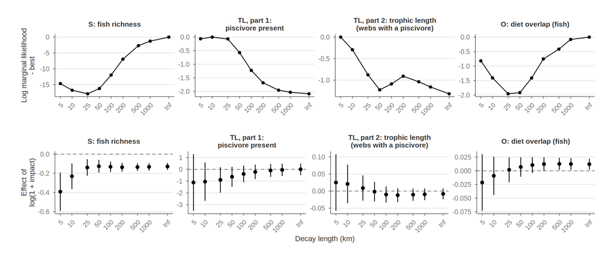

```r
decay_break <- c(5, 10, 25, 50, 100, 200, 500, 1000, 3000)
dam_decay_plot <- dam_decay |>
  mutate(lambda = if_else(is.finite(lambda), lambda, 3000))
patchwork::wrap_plots(
  ggplot(dam_decay_plot, aes(lambda, delta_mlik)) +
    geom_line() +
    geom_point() +
    facet_wrap(~response, nrow = 1, scales = "free_y") +
    scale_x_log10(breaks = decay_break, labels = c(head(decay_break, -1), "Inf")) +
    labs(x = NULL, y = "Log marginal likelihood\n- best"),
  ggplot(dam_decay_plot, aes(lambda, mean)) +
    geom_hline(yintercept = 0, linetype = "dashed", color = "grey50") +
    geom_pointrange(aes(ymin = lower, ymax = upper), size = 0.3) +
    facet_wrap(~response, nrow = 1, scales = "free_y") +
    scale_x_log10(breaks = decay_break, labels = c(head(decay_break, -1), "Inf")) +
    labs(x = "Decay length (km)", y = "Effect of\nlog(1 + impact)"),
  ncol = 1
) &
  theme(axis.text.x = element_text(angle = 45, hjust = 1))
```

### Dam effect along the altitude gradient

Does the dam effect change with altitude? The models (without richness as a covariate) are fitted with an interaction between log(1 + dams) and the log altitude, and compared by WAIC to the models without it. The dam effect at a given altitude is $\beta_D + \beta_{D \times H}\, H$, computed as a linear combination of the posterior for altitudes between the 5% and 95% quantiles of the visits.

```r
alt_value <- seq(
  quantile(foodweb_visit$log_alt, 0.05), quantile(foodweb_visit$log_alt, 0.95),
  length.out = 20
)

# Dam effect along the altitude and WAIC difference with the model without
# the interaction, for `response`.
fit_dam_altitude <- function(response) {
  data <- if (response == "trophic_length") filter(foodweb_visit, piscivore == 1) else foodweb_visit
  fit <- function(dam, ...) {
    INLA::inla(
      as.formula(paste(
        response, "~", dam, "+", control_term, "+ district + protocol + log_surface +",
        "f(site, model = 'iid') + f(year, model = 'iid')"
      )),
      family = foodweb_family[[response]], data = data, num.threads = 4,
      control.compute = list(waic = TRUE, config = FALSE), ...
    )
  }
  model <- fit(
    "accumulation + accumulation:log_alt",
    lincomb = INLA::inla.make.lincombs(
      accumulation = rep(1, length(alt_value)), `accumulation:log_alt` = alt_value
    )
  )
  waic_main <- fit("accumulation")$waic$waic
  coefficient <- model$summary.fixed["accumulation:log_alt", ]
  gc()
  tibble(
    response = response, altitude = exp(alt_value + mean(visit$log_altitude)),
    mean = model$summary.lincomb.derived$mean,
    lower = model$summary.lincomb.derived$`0.025quant`,
    upper = model$summary.lincomb.derived$`0.975quant`,
    interaction = coefficient$mean,
    interaction_lower = coefficient$`0.025quant`,
    interaction_upper = coefficient$`0.975quant`,
    delta_waic = model$waic$waic - waic_main
  )
}
dam_altitude <- lapply(names(foodweb_response), fit_dam_altitude) |>
  bind_rows() |>
  mutate(response = factor(response, names(foodweb_response), foodweb_response))
```

Effect of log(1 + dams) along the altitude (posterior mean and 95% credible interval); in each panel, the interaction coefficient and the WAIC difference with the model without it (negative: the interaction fits better).

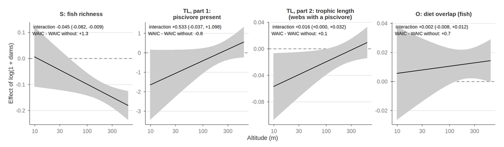

```r
dam_altitude |>
  ggplot(aes(altitude, mean)) +
  geom_hline(yintercept = 0, linetype = "dashed", color = "grey50") +
  geom_ribbon(aes(ymin = lower, ymax = upper), fill = "grey80") +
  geom_line() +
  geom_text(
    data = \(d) distinct(d, response, interaction, interaction_lower, interaction_upper, delta_waic),
    aes(
      x = 0, y = Inf,
      label = sprintf(
        "interaction %+.3f (%+.3f, %+.3f)\nWAIC - WAIC without: %+.1f",
        interaction, interaction_lower, interaction_upper, delta_waic
      )
    ),
    hjust = -0.05, vjust = 1.3, size = 2.8
  ) +
  facet_wrap(~response, nrow = 1, scales = "free_y") +
  scale_x_log10() +
  labs(x = "Altitude (m)", y = "Effect of log(1 + dams)")
```

**Results:** the loss of species with dams depends on altitude: in the lowlands, dams do not credibly change the number of species, while in the uplands they reduce it. The interaction is credible, but it does not improve the fit (WAIC), so this gradient should be read with care. For the structure metrics, the dam effect hardly changes with altitude, apart from slightly shorter chains with dams in the lowlands (at the edge of credibility).

## References

Dormann, Carsten F., Jane Elith, Sven Bacher, et al. 2013. “Collinearity: A Review of Methods to Deal with It and a Simulation Study Evaluating Their Performance.” *Ecography* 36 (1): 27–46. https://doi.org/10.1111/j.1600-0587.2012.07348.x.